# FinalProject

# 2) Models and inference

Since we saw we have many interesting features like losses, leaguePoints and tier, we will try to formulate different models with different number of parameters, seeking the one with lowest DIC.

Our first models will depend only on wins, leaguePoints and the tier, we will use jags from now to the end of the project.

As we analyzed before every feature we are able to define prior distributions for this parameters, such also our likelihood, so to speed up the computations and analysis we will perform our diagnostics and choose the best parameters from simulated data.

Note that the diagnostic and more will be performed only one the ‘best model’ found with every likelihood.

Based on the distributions available in jags and the similarity to our Wins we will assume likelihood to be a Double Exponential, Exponential, F-Distribution, Gamma Distribution, Generalized Gamma, Non Central t distribution, Weibull.

## Model assuming Likelihood as a Double Exponential

```r
#So for now we have to simulate the losses, leaguePoints and wins.

#the league points are generally uniform values from 0 to 100 (we saw it before)

# leaguePoints
LP = sample(0:100, size = 1500, replace = TRUE )

#Now the tier that can be assumed uniform since we created ourselfes the dataset!!!!
# We would like tr <- c('IRON', 'BRONZE', 'SILVER', 'GOLD', 'PLATINUM', 'DIAMOND')
#but for semplicity we write, remembering that it will not matter the value for us
#just a programming ease
tr <- c(1,2,3,4,5,6)
tier = sample(tr, 1500, replace = TRUE)


a1tiers <- c()

#initialize the parameters
for(i in 1:length(tr)){

    a1tiers <- c(a1tiers, runif(1,min = i, i*3 ))

    }
a1Lp <- 0.02
#now I simulate the wins
Wins <- c()
for( i in 1:1500){
  h <- -1
  while(h <0 ){
    h <- rdexp(1, 0.8, 50 + a1tiers[tier[i]]+a1Lp*LP[i])}

  Wins = c(Wins, h)

}
length(Wins)
```

```
## [1] 1500
```

```r
print(a1tiers)
```

```
## [1]  1.530799  4.200769  3.811468  9.454578  9.503511 10.399735
```

```r
print(a1Lp)
```

```
## [1] 0.02
```

```r
#Now i have simulated LP, Tier and Wins, We are ready to test our model!!!!!!!!

#We used this formula because as the tier goes  up, also teh distirbution goes to the right (more games) and so show the adaptatioin of the location of the double exp based on the elo. for the LP they make a little difference, but still more LP results usually in likely more wins
```

Let’s visualize a little what we simulated in respected to the real data

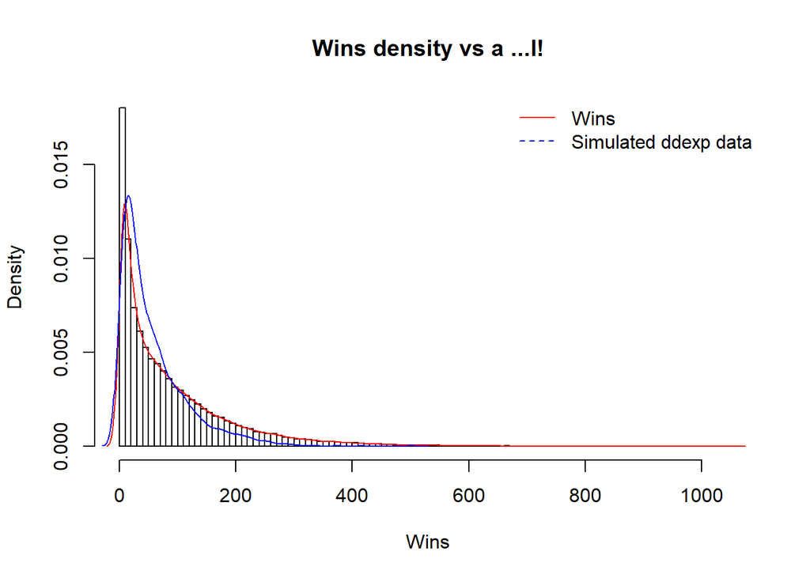

```r
hist(LeagueData$wins,
     breaks = 100,
     prob = TRUE,
     main = "Wins density vs a ...l!",
     xlab = "Wins")

## Sample density
lines(density(LeagueData$wins), col="red")

## Theoretical normal density
lines(density(Wins), col="Blue")

legend("topright", c("Wins", "Simulated ddexp data"),
       bty = "n", lty = c(1,2), col = c("red", "blue"))
```

```r
#I would say the plot (with only 1500 points) is not so bad!
```

### Let’s do the inference with ddexp!

Now we will our first model, based on a double exponential likelihood.

We will now start a long analysis in which we will define similar or particular models for every Likelihood assumption, examining first if the likelihood in exam is worth our attention.

```r
# MCMC inference ----------------------------------------------------------
#N <- 1500 #num of simulations length(Wins)
# Writing model for jags

set.seed(123)
model <- function() {
  # Likelihood
  for(i in 1:N)
  {
    #for now we leave that 0.8 as location and 50 as term into the rate, we will try some more model to see the DIC on it
    Wins[i]  ~ ddexp( 0.8 , 50 + a1[i])

    a1[i] <- a1tiers[tier[i]]+a1Lp*LP[i]

  }

  # Priors

  a1Lp ~ dunif(0, 0.05)

  for (i in 1 : tierstypes)
  {
    a1tiers[i] ~ dunif(i, i*3 ) #as explained we want it to grow with the rank
  }

}

# Preparing data for JAGS
#just a redeclaration!
Wins2 <- Wins
LP2 <- LP
tier2 <- tier
#tr2 <- c('IRON', 'BRONZE', 'SILVER', 'GOLD', 'PLATINUM', 'DIAMOND')
N2 <- length(Wins)
tierstypes2 <- length(tr)

dat.jags <- list(Wins = Wins2, LP = LP2, tier = tier2, N = N2, tierstypes = tierstypes2)

# Defining parameters of interest
mod.params <- c( 'a1tiers', 'a1Lp') #for now only 2

# Starting values

mod.inits <- function(){
  list(
        'a1tiers' = runif(6, 3, 3 ),
        'a1Lp' = runif(1,0, 0.9))

}
```

```r
set.seed(123)
mod.fit <- jags(data = dat.jags,                                    # DATA
                model.file = model, #inits = mod.inits,          # MODEL
                parameters.to.save = mod.params,
                n.chains = 3, n.iter = 9000, n.burnin = 1000, n.thin=10)
```

```
## module glm loaded
```

```r
#Autocorrelation produces clumpy samples that are unrepresentative, in the short run, of the true underlying posterior distribution. Therefore, if #possible, we would like to get rid of autocorrelation so that the MCMC sample provides a more precise estimate of the posterior sample. One way #to decrease autocorrelation is to thin the sample, using only every nth step.
```

```r
mod.fit
```

```
## Inference for Bugs model at "C:/Users/leona/AppData/Local/Temp/Rtmp0CiPRT/model26645c42422.txt", fit using jags,
##  3 chains, each with 9000 iterations (first 1000 discarded), n.thin = 10
##  n.sims = 2400 iterations saved
##            mu.vect sd.vect    2.5%     25%     50%     75%   97.5%  Rhat n.eff
## a1Lp             0   0.000       0       0       0       0       0 1.001  2400
## a1tiers[1]       1   0.000       1       1       1       1       1 1.000     1
## a1tiers[2]       2   0.000       2       2       2       2       2 1.000     1
## a1tiers[3]       3   0.000       3       3       3       3       3 1.000     1
## a1tiers[4]       4   0.000       4       4       4       4       4 1.000     1
## a1tiers[5]       5   0.000       5       5       5       5       5 1.000     1
## a1tiers[6]       6   0.000       6       6       6       6       6 1.000     1
## deviance   9057325   5.451 9057316 9057321 9057324 9057328 9057338 1.000     1
##
## For each parameter, n.eff is a crude measure of effective sample size,
## and Rhat is the potential scale reduction factor (at convergence, Rhat=1).
##
## DIC info (using the rule, pD = var(deviance)/2)
## pD = 14.8 and DIC = 9057339.8
## DIC is an estimate of expected predictive error (lower deviance is better).
```

```r
mod.fit$BUGSoutput$summary
```

```
##                    mean           sd         2.5%          25%          50%
## a1Lp       2.321414e-07 2.294239e-07 6.770858e-09 6.879409e-08 1.646620e-07
## a1tiers[1] 1.000075e+00 7.313818e-05 1.000002e+00 1.000022e+00 1.000053e+00
## a1tiers[2] 2.000070e+00 7.053593e-05 2.000002e+00 2.000020e+00 2.000050e+00
## a1tiers[3] 3.000072e+00 7.196133e-05 3.000002e+00 3.000020e+00 3.000051e+00
## a1tiers[4] 4.000072e+00 7.384518e-05 4.000002e+00 4.000021e+00 4.000047e+00
## a1tiers[5] 5.000068e+00 6.772584e-05 5.000002e+00 5.000020e+00 5.000047e+00
## a1tiers[6] 6.000075e+00 7.418214e-05 6.000002e+00 6.000022e+00 6.000053e+00
## deviance   9.057325e+06 5.450969e+00 9.057316e+06 9.057321e+06 9.057324e+06
##                     75%        97.5%     Rhat n.eff
## a1Lp       3.201773e-07 8.103181e-07 1.001203  2400
## a1tiers[1] 1.000104e+00 1.000272e+00 1.000000     1
## a1tiers[2] 2.000096e+00 2.000262e+00 1.000000     1
## a1tiers[3] 3.000099e+00 3.000270e+00 1.000000     1
## a1tiers[4] 4.000100e+00 4.000277e+00 1.000000     1
## a1tiers[5] 5.000094e+00 5.000246e+00 1.000000     1
## a1tiers[6] 6.000104e+00 6.000274e+00 1.000000     1
## deviance   9.057328e+06 9.057338e+06 1.000000     1
```

So in this case the model seems decend, even if the parameters are not exactly the same as before, let’s try a model2, alwasy with the same likelihood.

TO BE NOTED that simulating more in this case with a lot of data, and working more with the thin param, we can obtain a better DIC, that in any case is an informative parameter to comparate different models!

```r
model2 <- function() {
  # Likelihood
  for(i in 1:N)
  {
    #for now we leave that a new parameter instead of 0.8 as location and another as 50 as term into the rate
    Wins[i]  ~ ddexp( loc, 50 + a1[i])# a1[i])#, a2[i])

    a1[i] <- a1tiers[tier[i]]+a1Lp*LP[i]

  }

  # Priors

  a1Lp ~ dunif(0, 0.05)
  loc ~ dnorm(0.8, 0.5)
  for (i in 1 : tierstypes)
  {
    a1tiers[i] ~ dunif(i, i*3 ) #as explained we want it to grow with the rank
  }

}

mod.params2 <- c( 'a1tiers', 'a1Lp', 'loc')
```

```r
set.seed(123)
mod.fit <- jags(data = dat.jags,                                    # DATA
                model.file = model2, #inits = mod.inits,          # MODEL
                parameters.to.save = mod.params2,
                n.chains = 3, n.iter = 9000, n.burnin = 1000, n.thin=10)
#Autocorrelation produces clumpy samples that are unrepresentative, in the short run, of the true underlying posterior distribution. Therefore, if #possible, we would like to get rid of autocorrelation so that the MCMC sample provides a more precise estimate of the posterior sample. One way #to decrease autocorrelation is to thin the sample, using only every nth step.


mod.fit
```

```
## Inference for Bugs model at "C:/Users/leona/AppData/Local/Temp/Rtmp0CiPRT/model26644dd36d8d.txt", fit using jags,
##  3 chains, each with 9000 iterations (first 1000 discarded), n.thin = 10
##  n.sims = 2400 iterations saved
##                mu.vect sd.vect       2.5%         25%         50%        75%
## a1Lp             0.000   0.000       0.00       0.000       0.000       0.00
## a1tiers[1]       1.000   0.000       1.00       1.000       1.000       1.00
## a1tiers[2]       2.000   0.000       2.00       2.000       2.000       2.00
## a1tiers[3]       3.000   0.000       3.00       3.000       3.000       3.00
## a1tiers[4]       4.000   0.000       4.00       4.000       4.000       4.00
## a1tiers[5]       5.000   0.000       5.00       5.000       5.000       5.00
## a1tiers[6]       6.000   0.000       6.00       6.000       6.000       6.00
## loc             37.621   0.024      37.58      37.602      37.622      37.64
## deviance   6509548.046   5.377 6509539.31 6509544.072 6509547.416 6509551.39
##                  97.5%  Rhat n.eff
## a1Lp             0.000 1.001  2400
## a1tiers[1]       1.000 1.002  1800
## a1tiers[2]       2.000 1.000     1
## a1tiers[3]       3.000 1.000     1
## a1tiers[4]       4.000 1.000     1
## a1tiers[5]       5.000 1.000     1
## a1tiers[6]       6.000 1.000     1
## loc             37.666 1.001  2400
## deviance   6509559.848 1.000     1
##
## For each parameter, n.eff is a crude measure of effective sample size,
## and Rhat is the potential scale reduction factor (at convergence, Rhat=1).
##
## DIC info (using the rule, pD = var(deviance)/2)
## pD = 14.5 and DIC = 6509562.5
## DIC is an estimate of expected predictive error (lower deviance is better).
```

```r
mod.fit$BUGSoutput$summary
```

```
##                    mean           sd         2.5%          25%          50%
## a1Lp       3.240725e-07 3.195107e-07 8.172882e-09 9.544330e-08 2.298763e-07
## a1tiers[1] 1.000103e+00 1.043098e-04 1.000003e+00 1.000029e+00 1.000068e+00
## a1tiers[2] 2.000098e+00 9.760629e-05 2.000003e+00 2.000028e+00 2.000068e+00
## a1tiers[3] 3.000104e+00 1.034369e-04 3.000003e+00 3.000030e+00 3.000075e+00
## a1tiers[4] 4.000098e+00 9.788727e-05 4.000003e+00 4.000028e+00 4.000068e+00
## a1tiers[5] 5.000092e+00 8.996798e-05 5.000003e+00 5.000026e+00 5.000064e+00
## a1tiers[6] 6.000099e+00 9.898318e-05 6.000002e+00 6.000029e+00 6.000068e+00
## deviance   6.509548e+06 5.377011e+00 6.509539e+06 6.509544e+06 6.509547e+06
## loc        3.762142e+01 2.411304e-02 3.757994e+01 3.760174e+01 3.762153e+01
##                     75%        97.5%     Rhat n.eff
## a1Lp       4.519143e-07 1.176849e-06 1.000518  2400
## a1tiers[1] 1.000141e+00 1.000395e+00 1.001510  1800
## a1tiers[2] 2.000134e+00 2.000357e+00 1.000000     1
## a1tiers[3] 3.000148e+00 3.000377e+00 1.000000     1
## a1tiers[4] 4.000133e+00 4.000352e+00 1.000000     1
## a1tiers[5] 5.000129e+00 5.000332e+00 1.000000     1
## a1tiers[6] 6.000137e+00 6.000363e+00 1.000000     1
## deviance   6.509551e+06 6.509560e+06 1.000000     1
## loc        3.764030e+01 3.766649e+01 1.001174  2400
```

This model is clearly better than the previous one! Let’s see another because we are not quite so happy with the parameters still!

```r
set.seed(123)
model3 <- function() {
  # Likelihood
  for(i in 1:N)
  {
    #for now we leave that a new parameter instead of 0.8 as location and another as 50 as term into the rate
    Wins[i]  ~ ddexp( loc, rateBase + a1[i])

    a1[i] <- a1tiers[tier[i]]+a1Lp*LP[i]

  }

  # Priors

  a1Lp ~ dunif(0, 0.05)
  loc ~ dnorm(0.8, 0.5)
  rateBase ~ dnorm(50, 0.5)
  for (i in 1 : tierstypes)
  {
    a1tiers[i] ~ dunif(i, i*3 ) #as explained we want it to grow with the rank
  }

}
mod.params3 <- c( 'a1tiers', 'a1Lp', 'loc', 'rateBase')

mod.fit <- jags(data = dat.jags,                                    # DATA
                model.file = model3, #inits = mod.inits,          # MODEL
                parameters.to.save = mod.params3,
                n.chains = 3, n.iter = 9000, n.burnin = 1000, n.thin=10)
#Autocorrelation produces clumpy samples that are unrepresentative, in the short run, of the true underlying posterior distribution. Therefore, if #possible, we would like to get rid of autocorrelation so that the MCMC sample provides a more precise estimate of the posterior sample. One way #to decrease autocorrelation is to thin the sample, using only every nth step.


mod.fit
```

```
## Inference for Bugs model at "C:/Users/leona/AppData/Local/Temp/Rtmp0CiPRT/model26642913576c.txt", fit using jags,
##  3 chains, each with 9000 iterations (first 1000 discarded), n.thin = 10
##  n.sims = 2400 iterations saved
##               mu.vect sd.vect       2.5%        25%        50%        75%
## a1Lp            0.000   0.000      0.000      0.000      0.000      0.000
## a1tiers[1]      3.000   0.000      3.000      3.000      3.000      3.000
## a1tiers[2]      3.018   0.002      3.015      3.017      3.018      3.019
## a1tiers[3]      3.022   0.002      3.018      3.021      3.022      3.023
## a1tiers[4]      4.000   0.000      4.000      4.000      4.000      4.000
## a1tiers[5]      5.000   0.000      5.000      5.000      5.000      5.000
## a1tiers[6]      6.000   0.000      6.000      6.000      6.000      6.000
## loc            37.240   0.162     36.907     37.134     37.242     37.359
## rateBase       -2.994   0.001     -2.996     -2.995     -2.994     -2.994
## deviance   133376.757   7.864 133364.391 133370.843 133375.820 133381.732
##                 97.5%  Rhat n.eff
## a1Lp            0.000 1.001  2200
## a1tiers[1]      3.000 1.000     1
## a1tiers[2]      3.021 1.000  2400
## a1tiers[3]      3.025 1.001  2400
## a1tiers[4]      4.000 1.000     1
## a1tiers[5]      5.000 1.000     1
## a1tiers[6]      6.000 1.000     1
## loc            37.543 1.001  2400
## rateBase       -2.993 1.002  1200
## deviance   133394.156 1.000     1
##
## For each parameter, n.eff is a crude measure of effective sample size,
## and Rhat is the potential scale reduction factor (at convergence, Rhat=1).
##
## DIC info (using the rule, pD = var(deviance)/2)
## pD = 30.9 and DIC = 133407.7
## DIC is an estimate of expected predictive error (lower deviance is better).
```

```r
mod.fit$BUGSoutput$summary
```

```
##                     mean           sd          2.5%           25%           50%
## a1Lp        1.046564e-05 7.885793e-06  3.666207e-07  4.195229e-06  9.032192e-06
## a1tiers[1]  2.999968e+00 3.270228e-05  2.999877e+00  2.999956e+00  2.999978e+00
## a1tiers[2]  3.018051e+00 1.535301e-03  3.015202e+00  3.016979e+00  3.018022e+00
## a1tiers[3]  3.021716e+00 1.749836e-03  3.018422e+00  3.020512e+00  3.021667e+00
## a1tiers[4]  4.000097e+00 9.557100e-05  4.000003e+00  4.000029e+00  4.000067e+00
## a1tiers[5]  5.000097e+00 9.767550e-05  5.000003e+00  5.000028e+00  5.000065e+00
## a1tiers[6]  6.000100e+00 1.004791e-04  6.000003e+00  6.000030e+00  6.000068e+00
## deviance    1.333768e+05 7.864279e+00  1.333644e+05  1.333708e+05  1.333758e+05
## loc         3.724035e+01 1.622562e-01  3.690733e+01  3.713431e+01  3.724213e+01
## rateBase   -2.994414e+00 5.461453e-04 -2.995530e+00 -2.994776e+00 -2.994387e+00
##                      75%         97.5%     Rhat n.eff
## a1Lp        1.509760e-05  2.944587e-05 1.001283  2200
## a1tiers[1]  2.999991e+00  2.999999e+00 1.000000     1
## a1tiers[2]  3.019065e+00  3.021174e+00 1.000388  2400
## a1tiers[3]  3.022921e+00  3.025254e+00 1.000535  2400
## a1tiers[4]  4.000135e+00  4.000352e+00 1.000000     1
## a1tiers[5]  5.000136e+00  5.000345e+00 1.000000     1
## a1tiers[6]  6.000135e+00  6.000384e+00 1.000000     1
## deviance    1.333817e+05  1.333942e+05 1.000000     1
## loc         3.735935e+01  3.754289e+01 1.000882  2400
## rateBase   -2.994033e+00 -2.993428e+00 1.002055  1200
```

This model is by far the best, but if we look better the n.eff for some parameters is very low, this means that generally we have problems of autocorrelation! so when we will test on our real data we will have to play more with the think factor and probably with more chains!

## Model assuming Likelihood as a Exponential

```r
#So for now we have to simulate the losses, leaguePoints and wins.
set.seed(123)
#the league points are generally uniform values from 0 to 100 (we saw it before)

# leaguePoints
LP = sample(0:100, size = 1500, replace = TRUE )

#Now the tier that can be assumed uniform since we created ourselfes the dataset!!!!
# We would like tr <- c('IRON', 'BRONZE', 'SILVER', 'GOLD', 'PLATINUM', 'DIAMOND')
#but for semplicity we write, remembering that it will not matter the value for us
#just a programming ease
tr <- c(1,2,3,4,5,6)
tier = sample(tr, 1500, replace = TRUE)


#The kind of formulAS we want are the following

a1tiers <- c()

#initialize the parameters
for(i in 1:length(tr)){

    a1tiers <- c(a1tiers, rnorm(1,i, i ))

    }

a1Lp <- 0.0002

#now I simulate the wins
Wins <- c()
for( i in 1:1500){
  h <- -1
  while(h < 0 ){
    h <- rexp(1, rate = abs(0.3/(a1tiers[tier[i]]+(a1Lp*LP[i]))^2))}
  #print(h)

  Wins = c(Wins, h)

}
length(Wins)
```

```
## [1] 1500
```

```r
print(a1tiers)
```

```
## [1]  0.3732135 -0.2038728  2.6256767  2.8423341  9.7229273 10.2610643
```

```r
print(a1Lp)
```

```
## [1] 2e-04
```

```r
#Now i have simulated LP, Tier and Wins, We are ready to test our model!!!!!!!!

#We used this formula because as the tier goes  up, also teh distirbution goes to the right (more games) and so show the adaptatioin of the location of the exp based on the elo. for the LP they make a little difference, but still more LP results usually in likely more wins
```

Let’s visualize a little what we simulated in respected to the real data

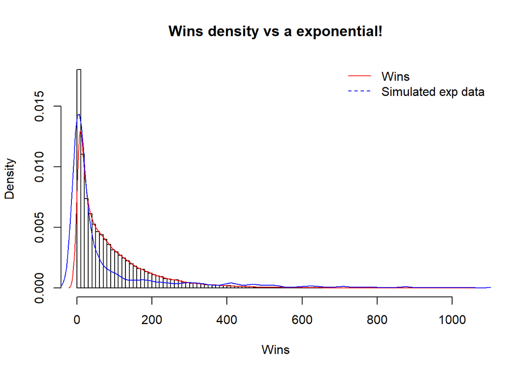

```r
hist(LeagueData$wins,
     breaks = 100,
     prob = TRUE,
     main = "Wins density vs a exponential!",
     xlab = "Wins")

## Sample density
lines(density(LeagueData$wins), col="red")

## Theoretical normal density
lines(density(Wins), col="Blue")

legend("topright", c("Wins", "Simulated exp data"),
       bty = "n", lty = c(1,2), col = c("red", "blue"))
```

```r
#I would say the plot (with only 1500 points) is not so bad!
```

Well this curve fits not very well, but can alwasy be our error, so let’s give it a shot with some models!

### Models with Exponential Likelihood

```r
set.seed(123)
#call it model4 since is the 4th of our project!

model4 <- function() {
  # Likelihood
  for(i in 1:N)
  {
    #for now we just leave the rate parameters as in simulation as dependence
    Wins[i]  ~ dexp( a1[i])# a1[i])#, a2[i])

    a1[i] <- (0.3/(a1tiers[tier[i]]+(a1Lp*LP[i]))^2)

  }

  # Priors

  a1Lp ~ dunif(0, 0.05)
  for (i in 1 : tierstypes)
  {
    a1tiers[i] ~ dnorm(i, i ) #as explained we want it to grow with the rank
  }

}

Wins2 <- Wins
LP2 <- LP
tier2 <- tier
#tr2 <- c('IRON', 'BRONZE', 'SILVER', 'GOLD', 'PLATINUM', 'DIAMOND')
N2 <- length(Wins)
tierstypes2 <- length(tr)

dat.jags <- list(Wins = Wins2, LP = LP2, tier = tier2, N = N2, tierstypes = tierstypes2)



mod.params4 <- c( 'a1tiers', 'a1Lp')

mod.fit <- jags(data = dat.jags,                                    # DATA
                model.file = model4, #inits = mod.inits,          # MODEL
                parameters.to.save = mod.params4,
                n.chains = 3, n.iter = 9000, n.burnin = 1000, n.thin=10)
#Autocorrelation produces clumpy samples that are unrepresentative, in the short run, of the true underlying posterior distribution. Therefore, if #possible, we would like to get rid of autocorrelation so that the MCMC sample provides a more precise estimate of the posterior sample. One way #to decrease autocorrelation is to thin the sample, using only every nth step.


mod.fit
```

```
## Inference for Bugs model at "C:/Users/leona/AppData/Local/Temp/Rtmp0CiPRT/model26646d9925f7.txt", fit using jags,
##  3 chains, each with 9000 iterations (first 1000 discarded), n.thin = 10
##  n.sims = 2400 iterations saved
##              mu.vect sd.vect      2.5%       25%       50%       75%     97.5%
## a1Lp           0.000   0.000     0.000     0.000     0.000     0.001     0.001
## a1tiers[1]     0.381   0.016     0.351     0.370     0.381     0.392     0.413
## a1tiers[2]    -0.218   0.012    -0.242    -0.227    -0.218    -0.210    -0.196
## a1tiers[3]     2.692   0.084     2.541     2.631     2.690     2.751     2.861
## a1tiers[4]     2.887   0.091     2.706     2.822     2.884     2.950     3.068
## a1tiers[5]     8.219   0.199     7.832     8.089     8.222     8.353     8.602
## a1tiers[6]     8.685   0.202     8.301     8.543     8.679     8.816     9.087
## deviance   10629.114   9.875 10611.891 10622.264 10628.386 10635.440 10648.854
##             Rhat n.eff
## a1Lp       1.001  2400
## a1tiers[1] 1.001  2400
## a1tiers[2] 1.002  1200
## a1tiers[3] 1.001  2400
## a1tiers[4] 1.001  2400
## a1tiers[5] 1.001  2400
## a1tiers[6] 1.001  2400
## deviance   1.001  2400
##
## For each parameter, n.eff is a crude measure of effective sample size,
## and Rhat is the potential scale reduction factor (at convergence, Rhat=1).
##
## DIC info (using the rule, pD = var(deviance)/2)
## pD = 48.8 and DIC = 10677.9
## DIC is an estimate of expected predictive error (lower deviance is better).
```

```r
mod.fit$BUGSoutput$summary
```

```
##                     mean           sd          2.5%           25%           50%
## a1Lp        4.094292e-04 0.0001838654  6.461579e-05  2.796183e-04  4.016772e-04
## a1tiers[1]  3.808309e-01 0.0161881898  3.512854e-01  3.697573e-01  3.805139e-01
## a1tiers[2] -2.184299e-01 0.0122942459 -2.423545e-01 -2.271117e-01 -2.179668e-01
## a1tiers[3]  2.692453e+00 0.0843448709  2.541423e+00  2.630721e+00  2.690066e+00
## a1tiers[4]  2.886609e+00 0.0909720266  2.706452e+00  2.821999e+00  2.883938e+00
## a1tiers[5]  8.219401e+00 0.1992245409  7.832116e+00  8.088974e+00  8.221680e+00
## a1tiers[6]  8.685042e+00 0.2020721517  8.300569e+00  8.543351e+00  8.678795e+00
## deviance    1.062911e+04 9.8749284505  1.061189e+04  1.062226e+04  1.062839e+04
##                      75%         97.5%     Rhat n.eff
## a1Lp        5.361114e-04  7.632140e-04 1.001148  2400
## a1tiers[1]  3.918056e-01  4.131105e-01 1.001010  2400
## a1tiers[2] -2.096218e-01 -1.957123e-01 1.002013  1200
## a1tiers[3]  2.751119e+00  2.860545e+00 1.001265  2400
## a1tiers[4]  2.950486e+00  3.068157e+00 1.001211  2400
## a1tiers[5]  8.352627e+00  8.602040e+00 1.000912  2400
## a1tiers[6]  8.816258e+00  9.086592e+00 1.000536  2400
## deviance    1.063544e+04  1.064885e+04 1.000574  2400
```

This is a pretty nice result, since is the first time we get a decent n.eff and a very good DIC, let’s try to move a little the model, adding a parameter! The problem is that the parameters are not quite right but in our defense we have that they came from normal distributions, and if we look better in the disteribution they are quite near the real values!

```r
set.seed(123)
#call it model5 since is the 5th of our project!

model5 <- function() {
  # Likelihood
  for(i in 1:N)
  {
    #for now we just leave the rate parameters as in simulation as dependence
    Wins[i]  ~ dexp( a1[i])

    a1[i] <- (base/(a1tiers[tier[i]]+(a1Lp*LP[i]))^2)

  }

  # Priors
  base ~ dunif(0.2, 0.6)
  a1Lp ~ dunif(0, 0.05)
  for (i in 1 : tierstypes)
  {
    a1tiers[i] ~ dnorm(i, i ) #as explained we want it to grow with the rank
  }

}
mod.params5 <- c( 'a1tiers', 'a1Lp', 'base')

mod.fit <- jags(data = dat.jags,                                    # DATA
                model.file = model5, #inits = mod.inits,          # MODEL
                parameters.to.save = mod.params5,
                n.chains = 3, n.iter = 9000, n.burnin = 1000, n.thin=10)
#Autocorrelation produces clumpy samples that are unrepresentative, in the short run, of the true underlying posterior distribution. Therefore, if #possible, we would like to get rid of autocorrelation so that the MCMC sample provides a more precise estimate of the posterior sample. One way #to decrease autocorrelation is to thin the sample, using only every nth step.


mod.fit
```

```
## Inference for Bugs model at "C:/Users/leona/AppData/Local/Temp/Rtmp0CiPRT/model2664365c1206.txt", fit using jags,
##  3 chains, each with 9000 iterations (first 1000 discarded), n.thin = 10
##  n.sims = 2400 iterations saved
##              mu.vect sd.vect      2.5%       25%       50%       75%     97.5%
## a1Lp           0.000   0.000     0.000     0.000     0.000     0.000     0.001
## a1tiers[1]     0.318   0.014     0.290     0.309     0.319     0.328     0.344
## a1tiers[2]    -0.067   0.158    -0.196    -0.181    -0.171     0.152     0.165
## a1tiers[3]     2.226   0.072     2.093     2.176     2.224     2.274     2.371
## a1tiers[4]     2.385   0.081     2.237     2.330     2.382     2.440     2.549
## a1tiers[5]     7.104   0.187     6.761     6.974     7.101     7.228     7.476
## a1tiers[6]     7.583   0.200     7.202     7.443     7.586     7.714     7.978
## base           0.203   0.003     0.200     0.201     0.202     0.204     0.212
## deviance   10608.499   6.714 10597.641 10603.648 10607.869 10612.561 10623.638
##              Rhat n.eff
## a1Lp        1.424     9
## a1tiers[1]  1.119    21
## a1tiers[2] 32.413     3
## a1tiers[3]  1.001  1900
## a1tiers[4]  1.012   180
## a1tiers[5]  1.000  2400
## a1tiers[6]  1.001  2400
## base        1.000  2400
## deviance    1.109    24
##
## For each parameter, n.eff is a crude measure of effective sample size,
## and Rhat is the potential scale reduction factor (at convergence, Rhat=1).
##
## DIC info (using the rule, pD = var(deviance)/2)
## pD = 20.6 and DIC = 10629.1
## DIC is an estimate of expected predictive error (lower deviance is better).
```

```r
mod.fit$BUGSoutput$summary
```

```
##                     mean           sd          2.5%           25%           50%
## a1Lp        2.511581e-04 0.0001560162  1.177586e-05  1.265658e-04  2.391342e-04
## a1tiers[1]  3.181676e-01 0.0136726763  2.902605e-01  3.086857e-01  3.186965e-01
## a1tiers[2] -6.661535e-02 0.1578085096 -1.955703e-01 -1.807858e-01 -1.711718e-01
## a1tiers[3]  2.225619e+00 0.0718288422  2.092553e+00  2.176313e+00  2.224363e+00
## a1tiers[4]  2.385059e+00 0.0812652583  2.236889e+00  2.329710e+00  2.381592e+00
## a1tiers[5]  7.103554e+00 0.1867797428  6.760840e+00  6.973791e+00  7.100895e+00
## a1tiers[6]  7.582820e+00 0.1999885872  7.201685e+00  7.442955e+00  7.585989e+00
## base        2.031976e-01 0.0031130739  2.000838e-01  2.009451e-01  2.022789e-01
## deviance    1.060850e+04 6.7136183016  1.059764e+04  1.060365e+04  1.060787e+04
##                     75%        97.5%      Rhat n.eff
## a1Lp       3.646967e-04 5.713178e-04  1.424268     9
## a1tiers[1] 3.275793e-01 3.440934e-01  1.119028    21
## a1tiers[2] 1.518637e-01 1.654219e-01 32.412837     3
## a1tiers[3] 2.273900e+00 2.371311e+00  1.001400  1900
## a1tiers[4] 2.439755e+00 2.548891e+00  1.011864   180
## a1tiers[5] 7.228397e+00 7.475736e+00  1.000418  2400
## a1tiers[6] 7.714274e+00 7.978156e+00  1.000959  2400
## base       2.044459e-01 2.116488e-01  1.000379  2400
## deviance   1.061256e+04 1.062364e+04  1.108554    24
```

So the two models are quite similar, still we would prefer the second because even if has more parameters (more comutational time) has a less pD and less DIC!

Now let’s go with another likelihood!

## Model assuming Likelihood as a F-Distribution

```r
#So for now we have to simulate the losses, leaguePoints and wins.
set.seed(123)
#the league points are generally uniform values from 0 to 100 (we saw it before)

# leaguePoints
LP = sample(0:100, size = 1500, replace = TRUE )

#Now the tier that can be assumed uniform since we created ourselfes the dataset!!!!
# We would like tr <- c('IRON', 'BRONZE', 'SILVER', 'GOLD', 'PLATINUM', 'DIAMOND')
#but for semplicity we write, remembering that it will not matter the value for us
#just a programming ease
tr <- c(1,2,3,4,5,6)
tier = sample(tr, 1500, replace = TRUE)


#The kind of formulAS we want are the following
# sd = sdLp*LP + sdtier['tier of the player']

a1tiers <- c()

#initialize the parameters
for(i in 1:length(tr)){

    a1tiers <- c(a1tiers, rnorm(1,i, i ))

    }

a1Lp <- 0.0002

#now I simulate the wins
Wins <- c()
for( i in 1:1500){
  h <- -1
  while(h < 0 ){
    h <- rf(1,9, 2) # i usually check with number first, and we didn't get a good match :()
   # h <- rexp(1, rate = abs(0.3/(a1tiers[tier[i]]+(a1Lp*LP[i]))^2))
    } #0.012

  Wins = c(Wins, h)

}
length(Wins)
```

```
## [1] 1500
```

```r
print(a1tiers)
```

```
## [1]  0.3732135 -0.2038728  2.6256767  2.8423341  9.7229273 10.2610643
```

```r
print(a1Lp)
```

```
## [1] 2e-04
```

```r
#Now i have simulated LP, Tier and Wins, We are ready to test our model!!!!!!!!

#We used this formula because as the tier goes  up, also teh distirbution goes to the right (more games) and so show the adaptatioin of the location of the F-distr based on the elo. for the LP they make a little difference, but still more LP results usually in likely more wins
```

Let’s visualize a little what we simulated in respected to the real data

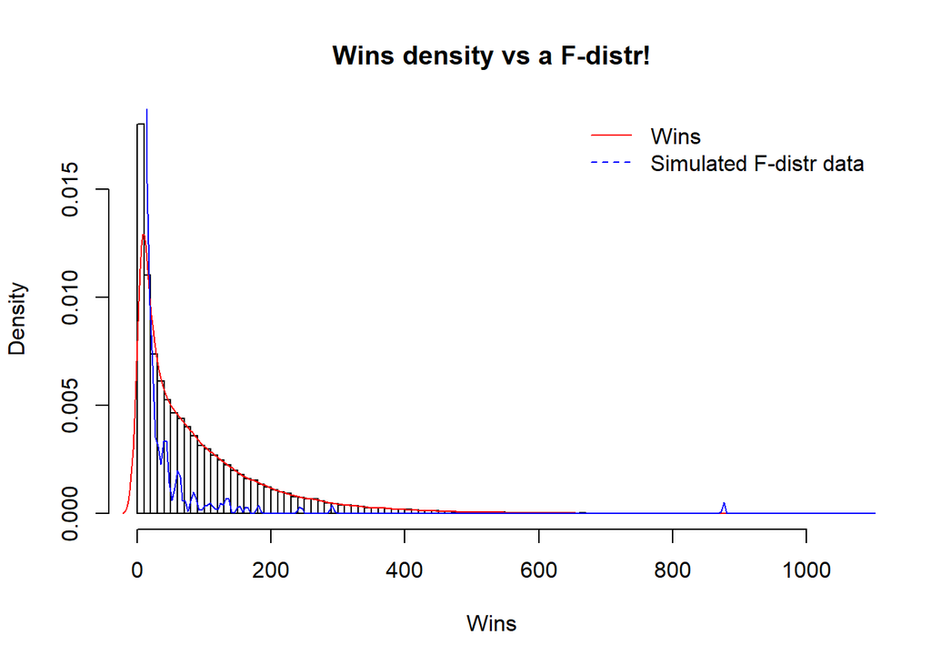

```r
hist(LeagueData$wins,
     breaks = 100,
     prob = TRUE,
     main = "Wins density vs a F-distr!",
     xlab = "Wins")

## Sample density
lines(density(LeagueData$wins), col="red")

## Theoretical normal density
lines(density(Wins), col="Blue")

legend("topright", c("Wins", "Simulated F-distr data"),
       bty = "n", lty = c(1,2), col = c("red", "blue"))
```

```r
#I would say the plot (with only 1500 points) is not so bad!
```

I tried in many ways, combinations of F dis, it seems thai distribution does not fit well our data, so we will not procede to develop a model with it, we go no to the Gamma.

## Model assuming Likelihood as a Gamma

```r
#So for now we have to simulate the losses, leaguePoints and wins.
set.seed(123)
#the league points are generally uniform values from 0 to 100 (we saw it before)

# leaguePoints
LP = sample(0:100, size = 1500, replace = TRUE )

#Now the tier that can be assumed uniform since we created ourselfes the dataset!!!!
# We would like tr <- c('IRON', 'BRONZE', 'SILVER', 'GOLD', 'PLATINUM', 'DIAMOND')
#but for semplicity we write, remembering that it will not matter the value for us
#just a programming ease
tr <- c(1,2,3,4,5,6)
tier = sample(tr, 1500, replace = TRUE)


#The kind of formulAS we want are the following

a1tiers <- c()

#initialize the parameters
for(i in 1:length(tr)){
  #  sdtiers <- c(sdtiers, runif(1,min = i, i+5 ))
    a1tiers <- c(a1tiers, rnorm(1,20, i/3 ))
  #  a2tiers <- c(a2tiers, runif(1,min = i, i+0.2 ))
    }

#now I simulate the wins
Wins <- c()
for( i in 1:1500){
  h <- -1
  while(h < 0 ){

     h <-  rgamma(1, shape = 101/(LP[i]+1), scale = (a1tiers[tier[i]]))

    } #0.012

  Wins = c(Wins, h)
}
length(Wins)
```

```
## [1] 1500
```

```r
print(a1tiers)
```

```
## [1] 19.79107 19.26538 19.87523 19.61411 21.57431 21.42035
```

```r
#Now i have simulated LP, Tier and Wins, We are ready to test our model!!!!!!!!

#We used this formula because as the tier goes  up, also teh distirbution goes to the right (more games) and so show the adaptatioin of the location of the double exp based on the elo. for the LP they make a little difference, but still more LP results usually in likely more wins
```

Let’s visualize a little what we simulated in respected to the real data

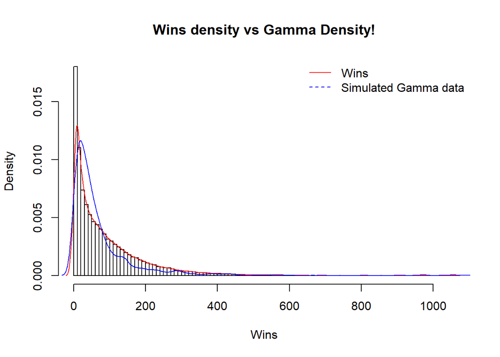

```r
hist(LeagueData$wins,
     breaks = 100,
     prob = TRUE,
     main = "Wins density vs Gamma Density!",
     xlab = "Wins")

## Sample density
lines(density(LeagueData$wins), col="red")

## Theoretical normal density
lines(density(Wins), col="Blue")

legend("topright", c("Wins", "Simulated Gamma data"),
       bty = "n", lty = c(1,2), col = c("red", "blue"))
```

```r
#I would say the plot (with only 1500 points) is not so bad!
```

We see that actually we can approximate decently our data, so we procede with some models!

```r
set.seed(123)
#call it model6 since is the 6th of our project!

model6 <- function() {
  # Likelihood
  for(i in 1:N)
  {
    #for now we just leave the rate parameters as in simulation as dependence
    Wins[i]  ~ dgamma( shape[i], scale[i])

    shape[i] <- base/(LP[i]+1)
    scale[i] <- a1tiers[tier[i]]

  }

  # Priors
  base ~ dunif(101, 105)
  for (i in 1 : tierstypes)
  {
    a1tiers[i] ~ dnorm(20, i/3 ) #as explained we want it to grow with the rank
  }

}


Wins2 <- Wins
LP2 <- LP
tier2 <- tier
#tr2 <- c('IRON', 'BRONZE', 'SILVER', 'GOLD', 'PLATINUM', 'DIAMOND')
N2 <- length(Wins)
tierstypes2 <- length(tr)

dat.jags <- list(Wins = Wins2, LP = LP2, tier = tier2, N = N2, tierstypes = tierstypes2)

mod.params6 <- c( 'a1tiers','base')

mod.fit <- jags(data = dat.jags,                                    # DATA
                model.file = model6, #inits = mod.inits,          # MODEL
                parameters.to.save = mod.params6,
                n.chains = 3, n.iter = 9000, n.burnin = 1000, n.thin=10)
#Autocorrelation produces clumpy samples that are unrepresentative, in the short run, of the true underlying posterior distribution. Therefore, if #possible, we would like to get rid of autocorrelation so that the MCMC sample provides a more precise estimate of the posterior sample. One way #to decrease autocorrelation is to thin the sample, using only every nth step.


mod.fit
```

```
## Inference for Bugs model at "C:/Users/leona/AppData/Local/Temp/Rtmp0CiPRT/model26645cc41833.txt", fit using jags,
##  3 chains, each with 9000 iterations (first 1000 discarded), n.thin = 10
##  n.sims = 2400 iterations saved
##              mu.vect sd.vect      2.5%       25%       50%       75%     97.5%
## a1tiers[1]     0.053   0.002     0.050     0.052     0.053     0.055     0.057
## a1tiers[2]     0.054   0.002     0.051     0.053     0.054     0.055     0.058
## a1tiers[3]     0.051   0.002     0.048     0.050     0.051     0.052     0.054
## a1tiers[4]     0.050   0.001     0.047     0.049     0.050     0.051     0.053
## a1tiers[5]     0.047   0.001     0.045     0.046     0.047     0.048     0.050
## a1tiers[6]     0.048   0.001     0.045     0.047     0.048     0.049     0.050
## base         103.011   1.108   101.147   102.121   103.019   103.941   104.895
## deviance   14085.314   3.391 14080.552 14082.838 14084.637 14087.157 14093.311
##             Rhat n.eff
## a1tiers[1] 1.001  2400
## a1tiers[2] 1.002  1200
## a1tiers[3] 1.002  1500
## a1tiers[4] 1.003   870
## a1tiers[5] 1.001  2300
## a1tiers[6] 1.005   650
## base       1.003   900
## deviance   1.001  2400
##
## For each parameter, n.eff is a crude measure of effective sample size,
## and Rhat is the potential scale reduction factor (at convergence, Rhat=1).
##
## DIC info (using the rule, pD = var(deviance)/2)
## pD = 5.8 and DIC = 14091.1
## DIC is an estimate of expected predictive error (lower deviance is better).
```

```r
mod.fit$BUGSoutput$summary
```

```
##                    mean          sd         2.5%          25%          50%
## a1tiers[1] 5.342059e-02 0.001761986 5.007688e-02 5.223487e-02 5.341232e-02
## a1tiers[2] 5.425633e-02 0.001796109 5.066070e-02 5.304014e-02 5.425635e-02
## a1tiers[3] 5.087331e-02 0.001535689 4.790134e-02 4.983984e-02 5.084300e-02
## a1tiers[4] 5.003043e-02 0.001485796 4.720862e-02 4.902204e-02 5.000521e-02
## a1tiers[5] 4.731670e-02 0.001425408 4.456283e-02 4.635831e-02 4.728008e-02
## a1tiers[6] 4.791654e-02 0.001331534 4.531404e-02 4.700983e-02 4.789759e-02
## base       1.030111e+02 1.108317878 1.011467e+02 1.021213e+02 1.030189e+02
## deviance   1.408531e+04 3.391409033 1.408055e+04 1.408284e+04 1.408464e+04
##                     75%        97.5%     Rhat n.eff
## a1tiers[1] 5.459193e-02 5.699653e-02 1.000512  2400
## a1tiers[2] 5.546098e-02 5.778643e-02 1.002089  1200
## a1tiers[3] 5.189450e-02 5.404279e-02 1.001688  1500
## a1tiers[4] 5.095685e-02 5.302274e-02 1.002690   870
## a1tiers[5] 4.830561e-02 5.014763e-02 1.001262  2300
## a1tiers[6] 4.882582e-02 5.048852e-02 1.004919   650
## base       1.039414e+02 1.048955e+02 1.002597   900
## deviance   1.408716e+04 1.409331e+04 1.000832  2400
```

Is not bad even if our a1tiers are pretty far from the true ones! But let’s try to free some more paramters. Let’s try something different

```r
set.seed(123)
#call it model7 since is the 7th of our project!

model7 <- function() {
  # Likelihood
  for(i in 1:N)
  {
    #for now we just leave the rate parameters as in simulation as dependence
    Wins[i]  ~ dgamma( shape[i], scale[i])

    shape[i] <- base/(LP[i]+alpha)
    scale[i] <- a1tiers[tier[i]]

  }

  # Priors
  alpha ~ dunif(0.9, 1.3)
  base ~ dunif(101, 105)
  for (i in 1 : tierstypes)
  {
    a1tiers[i] ~ dunif(20-i/3,  20 + i/3 ) #as explained we want it to grow with the rank
  }

}


mod.params7 <- c( 'a1tiers','base', 'alpha')

mod.fit <- jags(data = dat.jags,                                    # DATA
                model.file = model7, #inits = mod.inits,          # MODEL
                parameters.to.save = mod.params7,
                n.chains = 3, n.iter = 9000, n.burnin = 1000, n.thin=10)
#Autocorrelation produces clumpy samples that are unrepresentative, in the short run, of the true underlying posterior distribution. Therefore, if #possible, we would like to get rid of autocorrelation so that the MCMC sample provides a more precise estimate of the posterior sample. One way #to decrease autocorrelation is to thin the sample, using only every nth step.


mod.fit
```

```
## Inference for Bugs model at "C:/Users/leona/AppData/Local/Temp/Rtmp0CiPRT/model266490f4b75.txt", fit using jags,
##  3 chains, each with 9000 iterations (first 1000 discarded), n.thin = 10
##  n.sims = 2400 iterations saved
##                mu.vect sd.vect        2.5%         25%         50%         75%
## a1tiers[1]      19.667   0.000      19.667      19.667      19.667      19.667
## a1tiers[2]      19.333   0.000      19.333      19.333      19.333      19.333
## a1tiers[3]      19.000   0.000      19.000      19.000      19.000      19.000
## a1tiers[4]      18.667   0.000      18.667      18.667      18.667      18.667
## a1tiers[5]      18.333   0.000      18.333      18.333      18.333      18.333
## a1tiers[6]      18.000   0.000      18.000      18.000      18.000      18.000
## alpha            0.900   0.000       0.900       0.900       0.900       0.900
## base           104.998   0.002     104.991     104.997     104.998     104.999
## deviance   5298258.071   5.453 5298249.176 5298254.081 5298257.562 5298261.323
##                  97.5% Rhat n.eff
## a1tiers[1]      19.667    1     1
## a1tiers[2]      19.334    1     1
## a1tiers[3]      19.000    1     1
## a1tiers[4]      18.667    1     1
## a1tiers[5]      18.333    1     1
## a1tiers[6]      18.000    1     1
## alpha            0.900    1     1
## base           105.000    1     1
## deviance   5298270.433    1     1
##
## For each parameter, n.eff is a crude measure of effective sample size,
## and Rhat is the potential scale reduction factor (at convergence, Rhat=1).
##
## DIC info (using the rule, pD = var(deviance)/2)
## pD = 14.9 and DIC = 5298272.9
## DIC is an estimate of expected predictive error (lower deviance is better).
```

```r
mod.fit$BUGSoutput$summary
```

```
##                    mean           sd         2.5%          25%          50%
## a1tiers[1] 1.966672e+01 5.278078e-05 1.966667e+01 1.966668e+01 1.966670e+01
## a1tiers[2] 1.933339e+01 5.478480e-05 1.933333e+01 1.933335e+01 1.933337e+01
## a1tiers[3] 1.900004e+01 4.280021e-05 1.900000e+01 1.900001e+01 1.900003e+01
## a1tiers[4] 1.866671e+01 3.886611e-05 1.866667e+01 1.866668e+01 1.866670e+01
## a1tiers[5] 1.833337e+01 3.971939e-05 1.833333e+01 1.833334e+01 1.833336e+01
## a1tiers[6] 1.800003e+01 3.128638e-05 1.800000e+01 1.800001e+01 1.800002e+01
## alpha      9.000796e-01 7.982401e-05 9.000020e-01 9.000241e-01 9.000551e-01
## base       1.049977e+02 2.348887e-03 1.049914e+02 1.049967e+02 1.049984e+02
## deviance   5.298258e+06 5.453166e+00 5.298249e+06 5.298254e+06 5.298258e+06
##                     75%        97.5% Rhat n.eff
## a1tiers[1] 1.966674e+01 1.966686e+01    1     1
## a1tiers[2] 1.933341e+01 1.933353e+01    1     1
## a1tiers[3] 1.900006e+01 1.900016e+01    1     1
## a1tiers[4] 1.866672e+01 1.866680e+01    1     1
## a1tiers[5] 1.833339e+01 1.833348e+01    1     1
## a1tiers[6] 1.800005e+01 1.800011e+01    1     1
## alpha      9.001081e-01 9.002967e-01    1     1
## base       1.049994e+02 1.049999e+02    1     1
## deviance   5.298261e+06 5.298270e+06    1     1
```

```r
set.seed(123)
#call it model8 since is the 8th of our project!

model8 <- function() {
  # Likelihood
  for(i in 1:N)
  {
    #for now we just leave the rate parameters as in simulation as dependence
    Wins[i]  ~ dgamma( shape[i], scale[i])

    shape[i] <- base/(LP[i]+1)
    scale[i] <- a1tiers[tier[i]]

  }

  # Priors
  base ~ dunif(101, 105)
  for (i in 1 : tierstypes)
  {
    a1tiers[i] ~ dunif(20-i/3,  20 + i/3 ) #as explained we want it to grow with the rank
  }

}


mod.params8 <- c( 'a1tiers','base')

mod.fit <- jags(data = dat.jags,                                    # DATA
                model.file = model8, #inits = mod.inits,          # MODEL
                parameters.to.save = mod.params8,
                n.chains = 3, n.iter = 9000, n.burnin = 1000, n.thin=10)
#Autocorrelation produces clumpy samples that are unrepresentative, in the short run, of the true underlying posterior distribution. Therefore, if #possible, we would like to get rid of autocorrelation so that the MCMC sample provides a more precise estimate of the posterior sample. One way #to decrease autocorrelation is to thin the sample, using only every nth step.


mod.fit
```

```
## Inference for Bugs model at "C:/Users/leona/AppData/Local/Temp/Rtmp0CiPRT/model26641de01366.txt", fit using jags,
##  3 chains, each with 9000 iterations (first 1000 discarded), n.thin = 10
##  n.sims = 2400 iterations saved
##                mu.vect sd.vect        2.5%         25%         50%         75%
## a1tiers[1]      19.667   0.000      19.667      19.667      19.667      19.667
## a1tiers[2]      19.333   0.000      19.333      19.333      19.333      19.333
## a1tiers[3]      19.000   0.000      19.000      19.000      19.000      19.000
## a1tiers[4]      18.667   0.000      18.667      18.667      18.667      18.667
## a1tiers[5]      18.333   0.000      18.333      18.333      18.333      18.333
## a1tiers[6]      18.000   0.000      18.000      18.000      18.000      18.000
## base           104.998   0.002     104.991     104.997     104.998     104.999
## deviance   5300605.458   5.310 5300597.144 5300601.595 5300604.741 5300608.637
##                  97.5% Rhat n.eff
## a1tiers[1]      19.667    1     1
## a1tiers[2]      19.334    1     1
## a1tiers[3]      19.000    1     1
## a1tiers[4]      18.667    1     1
## a1tiers[5]      18.333    1     1
## a1tiers[6]      18.000    1     1
## base           105.000    1     1
## deviance   5300616.896    1     1
##
## For each parameter, n.eff is a crude measure of effective sample size,
## and Rhat is the potential scale reduction factor (at convergence, Rhat=1).
##
## DIC info (using the rule, pD = var(deviance)/2)
## pD = 14.1 and DIC = 5300619.6
## DIC is an estimate of expected predictive error (lower deviance is better).
```

```r
mod.fit$BUGSoutput$summary
```

```
##                    mean           sd         2.5%          25%          50%
## a1tiers[1] 1.966672e+01 5.140857e-05 1.966667e+01 1.966668e+01 1.966670e+01
## a1tiers[2] 1.933339e+01 5.492160e-05 1.933333e+01 1.933335e+01 1.933337e+01
## a1tiers[3] 1.900004e+01 4.455648e-05 1.900000e+01 1.900001e+01 1.900003e+01
## a1tiers[4] 1.866671e+01 3.872842e-05 1.866667e+01 1.866668e+01 1.866669e+01
## a1tiers[5] 1.833337e+01 3.954159e-05 1.833333e+01 1.833334e+01 1.833336e+01
## a1tiers[6] 1.800003e+01 3.239913e-05 1.800000e+01 1.800001e+01 1.800002e+01
## base       1.049975e+02 2.441472e-03 1.049908e+02 1.049966e+02 1.049983e+02
## deviance   5.300605e+06 5.310317e+00 5.300597e+06 5.300602e+06 5.300605e+06
##                     75%        97.5% Rhat n.eff
## a1tiers[1] 1.966674e+01 1.966686e+01    1     1
## a1tiers[2] 1.933341e+01 1.933354e+01    1     1
## a1tiers[3] 1.900006e+01 1.900016e+01    1     1
## a1tiers[4] 1.866672e+01 1.866681e+01    1     1
## a1tiers[5] 1.833339e+01 1.833348e+01    1     1
## a1tiers[6] 1.800004e+01 1.800012e+01    1     1
## base       1.049993e+02 1.049999e+02    1     1
## deviance   5.300609e+06 5.300617e+06    1     1
```

Still very high DIC:( Remains the Weibull.

## Model assuming Likelihood as a Weibull distribution

```r
#So for now we have to simulate the losses, leaguePoints and wins.
set.seed(123)
#the league points are generally uniform values from 0 to 100 (we saw it before)

# leaguePoints
LP = sample(0:100, size = 1500, replace = TRUE )

#Now the tier that can be assumed uniform since we created ourselfes the dataset!!!!
# We would like tr <- c('IRON', 'BRONZE', 'SILVER', 'GOLD', 'PLATINUM', 'DIAMOND')
#but for semplicity we write, remembering that it will not matter the value for us
#just a programming ease
tr <- c(1,2,3,4,5,6)
tier = sample(tr, 1500, replace = TRUE)


#The kind of formulAS we want are the following
# sd = sdLp*LP + sdtier['tier of the player']
a1tiers <- c()
#initialize the parameters
for(i in 1:length(tr)){

    a1tiers <- c(a1tiers, runif(1,0.8-1/i^2, 0.9+1/i^2 ))

    }

#now I simulate the wins
Wins <- c()
for( i in 1:1500){
  h <- -1
  while(h < 0 ){
     h <-  rweibull(1, shape = a1tiers[tier[i]], scale = LP[i]/100 + (100-LP[i]))
    } #0.012


  Wins = c(Wins, h)

}
length(Wins)
```

```
## [1] 1500
```

```r
print(a1tiers)
```

```
## [1] 0.3573392 0.8801153 0.7324677 0.8909100 0.8410632 0.8292558
```

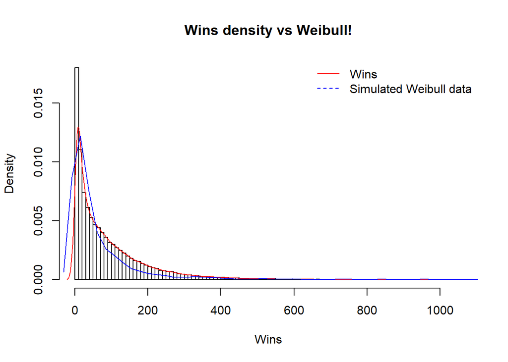

```r
#print(a1Lp)


#Now i have simulated LP, Tier and Wins, We are ready to test our model!!!!!!!!

#We used this formula because as the tier goes  up, also teh distirbution goes to the right (more games) and so show the adaptatioin of the location of the double exp based on the elo. for the LP they make a little difference, but still more LP results usually in likely more wins


#Let's visualize a little what we simulated in respected to the real data

hist(LeagueData$wins,
     breaks = 100,
     prob = TRUE,
     main = "Wins density vs Weibull!",
     xlab = "Wins")

## Sample density
lines(density(LeagueData$wins), col="red")

## Theoretical normal density
lines(density(Wins), col="Blue")

legend("topright", c("Wins", "Simulated Weibull data"),
       bty = "n", lty = c(1,2), col = c("red", "blue"))
```

```r
#I would say the plot (with only 1500 points) is not so bad!
```

We see that for rweibull(1, shape = 0.8, scale = 100) it fits almost perfectly!!!

So let’s go with the models!

```r
set.seed(123)
#call it model9 since is the 9th of our project!

model9 <- function() {
  # Likelihood
  for(i in 1:N)
  {
    Wins[i]  ~ dweibull( shape[i], scale[i])

    shape[i] <- a1tiers[tier[i]]
    scale[i] <-  LP[i]/alpha + (alpha-LP[i])

  }
  # Priors
  alpha ~ dunif(95, 105)
  for (i in 1 : tierstypes)
  {
    a1tiers[i] ~ dunif(0.8-1/i^2, 0.9+1/i^2 ) #as explained we want it to grow with the rank
  }

}


Wins2 <- Wins
LP2 <- LP
tier2 <- tier
#tr2 <- c('IRON', 'BRONZE', 'SILVER', 'GOLD', 'PLATINUM', 'DIAMOND')
N2 <- length(Wins)
tierstypes2 <- length(tr)

dat.jags <- list(Wins = Wins2, LP = LP2, tier = tier2, N = N2, tierstypes = tierstypes2)

mod.params9 <- c( 'a1tiers','alpha')

mod.fit <- jags(data = dat.jags,                                    # DATA
                model.file = model9, #inits = mod.inits,          # MODEL
                parameters.to.save = mod.params9,
                n.chains = 3, n.iter = 9000, n.burnin = 1000, n.thin=10)
#Autocorrelation produces clumpy samples that are unrepresentative, in the short run, of the true underlying posterior distribution. Therefore, if #possible, we would like to get rid of autocorrelation so that the MCMC sample provides a more precise estimate of the posterior sample. One way #to decrease autocorrelation is to thin the sample, using only every nth step.


mod.fit
```

```
## Inference for Bugs model at "C:/Users/leona/AppData/Local/Temp/Rtmp0CiPRT/model26644c177a36.txt", fit using jags,
##  3 chains, each with 9000 iterations (first 1000 discarded), n.thin = 10
##  n.sims = 2400 iterations saved
##                mu.vect sd.vect        2.5%         25%         50%         75%
## a1tiers[1]       0.008   0.000       0.007       0.008       0.008       0.008
## a1tiers[2]       0.550   0.000       0.550       0.550       0.550       0.550
## a1tiers[3]       0.689   0.000       0.689       0.689       0.689       0.689
## a1tiers[4]       0.738   0.000       0.738       0.738       0.738       0.738
## a1tiers[5]       0.760   0.000       0.760       0.760       0.760       0.760
## a1tiers[6]       0.772   0.000       0.772       0.772       0.772       0.772
## alpha           98.991   0.000      98.990      98.991      98.991      98.991
## deviance   2433166.053   5.058 2433158.348 2433162.345 2433165.239 2433169.042
##                  97.5%  Rhat n.eff
## a1tiers[1]       0.009 1.001  2400
## a1tiers[2]       0.550 1.000     1
## a1tiers[3]       0.689 1.000     1
## a1tiers[4]       0.738 1.000     1
## a1tiers[5]       0.760 1.000     1
## a1tiers[6]       0.772 1.000     1
## alpha           98.991 1.000     1
## deviance   2433177.724 1.000     1
##
## For each parameter, n.eff is a crude measure of effective sample size,
## and Rhat is the potential scale reduction factor (at convergence, Rhat=1).
##
## DIC info (using the rule, pD = var(deviance)/2)
## pD = 12.8 and DIC = 2433178.9
## DIC is an estimate of expected predictive error (lower deviance is better).
```

```r
mod.fit$BUGSoutput$summary
```

```
##                    mean           sd         2.5%          25%          50%
## a1tiers[1] 7.927532e-03 4.941089e-04 6.987962e-03 7.593251e-03 7.920969e-03
## a1tiers[2] 5.500024e-01 2.503924e-06 5.500001e-01 5.500007e-01 5.500017e-01
## a1tiers[3] 6.888898e-01 9.041802e-07 6.888889e-01 6.888891e-01 6.888895e-01
## a1tiers[4] 7.375007e-01 6.679070e-07 7.375000e-01 7.375002e-01 7.375004e-01
## a1tiers[5] 7.600008e-01 7.680563e-07 7.600000e-01 7.600002e-01 7.600005e-01
## a1tiers[6] 7.722230e-01 7.882418e-07 7.722222e-01 7.722225e-01 7.722228e-01
## alpha      9.899067e+01 2.158670e-04 9.899029e+01 9.899053e+01 9.899065e+01
## deviance   2.433166e+06 5.058151e+00 2.433158e+06 2.433162e+06 2.433165e+06
##                     75%        97.5%     Rhat n.eff
## a1tiers[1] 8.256192e-03 8.923638e-03 1.000567  2400
## a1tiers[2] 5.500034e-01 5.500095e-01 1.000000     1
## a1tiers[3] 6.888901e-01 6.888921e-01 1.000000     1
## a1tiers[4] 7.375009e-01 7.375025e-01 1.000000     1
## a1tiers[5] 7.600011e-01 7.600029e-01 1.000000     1
## a1tiers[6] 7.722233e-01 7.722252e-01 1.000000     1
## alpha      9.899080e+01 9.899116e+01 1.000000     1
## deviance   2.433169e+06 2.433178e+06 1.000000     1
```

The DIC is extremely high, still the model seems correct.

Now is time to take the real data, test the best models and decide which has less DIC, studying a little its diagnostics to be sure of our results!!!!!

# Test of the best models on our real Data

## Data loading!

```r
set.seed(123)
LeagueData <- read.csv("ProjectFinaldataLeagueofLegends.csv")
#Let's first drop the column X since we already have automatic indexes
LeagueData = subset(LeagueData, select = -c(X) )
head(LeagueData)
```

```
##   tier     summonerName leaguePoints wins losses veteran
## 1 GOLD           T0kki3           52  183    169    True
## 2 GOLD    CrimsÃ\230nBlade            0   52     49   False
## 3 GOLD     I LIKE FLIES          100   56     56   False
## 4 GOLD     DaKin Kowine            2  197    191   False
## 5 GOLD AnatolÃ®an eagle            0    2     10   False
## 6 GOLD     TOXIC I Himi           18  174    197   False
```

We want now to map the ranks with integers from 1 to 6 as in our models, and prepare everything for jags!!!

```r
#Change every IRON ->1, BRONZE->2 etc
Changer <- function(LeagueData_tier){
ChangedTier <- c()
for(i in LeagueData_tier){
  if(i == 'IRON'){
    ChangedTier <- c(ChangedTier, 1)

  }
  else if(i == 'BRONZE') {
    ChangedTier <- c(ChangedTier, 2)
  }
  else if(i == 'SILVER'){
    ChangedTier <- c(ChangedTier, 3)
    }
  else if(i == 'GOLD'){
    ChangedTier <- c(ChangedTier, 4)
  }
  else if(i == 'PLATINUM'){
    ChangedTier <- c(ChangedTier, 5)
  }
  else if(i == 'DIAMOND'){
    ChangedTier <- c(ChangedTier, 6)
  }
}
return(ChangedTier)
}
```

## Test the models!

Let’s remember that some of them presented high DIC or low n.eff, we hope to ajust it with a long sampling and thinning!

Now we will see the model3, and depending on how long will take we will test some of the others!

```r
#we have to take 1500 for every rank!
#so we make a copy of our dataset, and we drop lines!
COPY<-data.frame(LeagueData)
head(COPY)
```

```
##   tier     summonerName leaguePoints wins losses veteran
## 1 GOLD           T0kki3           52  183    169    True
## 2 GOLD    CrimsÃ\230nBlade            0   52     49   False
## 3 GOLD     I LIKE FLIES          100   56     56   False
## 4 GOLD     DaKin Kowine            2  197    191   False
## 5 GOLD AnatolÃ®an eagle            0    2     10   False
## 6 GOLD     TOXIC I Himi           18  174    197   False
```

```r
#Indexes <- c()
Iron <- which(COPY$tier == 'IRON')[1:1050]
Bronze <-which(COPY$tier == 'BRONZE')[1:1050]
Silver <-which(COPY$tier == 'SILVER')[1:1050]
Gold <-which(COPY$tier == 'GOLD')[1:1050]
Platinum <-which(COPY$tier == 'PLATINUM')[1:1050]
Diamond <- which(COPY$tier == 'DIAMOND')[1:1050]
Indexes<- c(Iron, Bronze, Silver, Gold, Platinum, Diamond)
head(COPY[Indexes,] ) #That's the subset
```

```
##       tier   summonerName leaguePoints wins losses veteran
## 19804 IRON        krstos1           75   60     79   False
## 19805 IRON       duktrill           31   14     25   False
## 19806 IRON jetz komme ich            7    7     46   False
## 19807 IRON sandrius922002           58    4     12   False
## 19808 IRON    DR procktor            6   18     31   False
## 19809 IRON       mamomo96           29    7     18   False
```

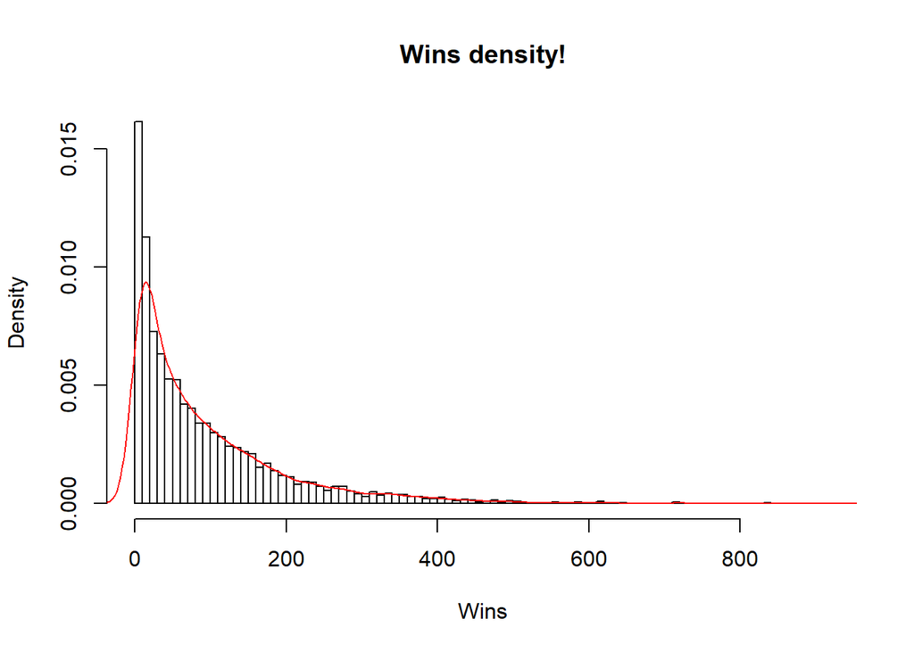

```r
COPY2 <- COPY[Indexes,]

#check the plot
hist(COPY2$wins,
     breaks = 100,
     prob = TRUE,
     main = "Wins density!",
     xlab = "Wins")

## Sample density
lines(density(COPY2$wins), col="red") #kinda perfectly as before ehehe
```

```r
tier2 <- Changer(COPY2$tier)
```

```r
set.seed(123)


Wins2 <- COPY2$wins
LP2 <- COPY2$leaguePoints
tier2 <- tier2
N2 <- length(Wins2)
tierstypes2 <- 6 #number of tiers

dat.jags <- list(Wins = Wins2, LP = LP2, tier = tier2, N = N2, tierstypes = tierstypes2)
```

```r
model3 <- function() {
  # Likelihood
  for(i in 1:N)
  {
    #for now we leave that a new parameter instead of 0.8 as location and another as 50 as term into the rate
    Wins[i]  ~ ddexp( loc, rateBase + a1[i])# a1[i])#, a2[i])

    a1[i] <- a1tiers[tier[i]]+a1Lp*LP[i]

  }

  # Priors

  a1Lp ~ dunif(0, 0.05)
  loc ~ dnorm(0.8, 0.5)
  rateBase ~ dnorm(50, 0.5)
  for (i in 1 : tierstypes)
  {
    a1tiers[i] ~ dunif(i, i*3 ) #as explained we want it to grow with the rank
  }

}
mod.params3 <- c( 'a1tiers', 'a1Lp', 'loc', 'rateBase')

mod.fit <- jags(data = dat.jags,                                    # DATA
                model.file = model3, #inits = mod.inits,          # MODEL
                parameters.to.save = mod.params3,
                n.chains = 3, n.iter = 9000, n.burnin = 1000, n.thin=10)
#Autocorrelation produces clumpy samples that are unrepresentative, in the short run, of the true underlying posterior distribution. Therefore, if #possible, we would like to get rid of autocorrelation so that the MCMC sample provides a more precise estimate of the posterior sample. One way #to decrease autocorrelation is to thin the sample, using only every nth step.


mod.fit
```

```
## Inference for Bugs model at "C:/Users/leona/AppData/Local/Temp/Rtmp0CiPRT/model26642459781f.txt", fit using jags,
##  3 chains, each with 9000 iterations (first 1000 discarded), n.thin = 10
##  n.sims = 2400 iterations saved
##                mu.vect sd.vect        2.5%         25%         50%         75%
## a1Lp             0.000   0.000       0.000       0.000       0.000       0.000
## a1tiers[1]       3.000   0.000       3.000       3.000       3.000       3.000
## a1tiers[2]       3.008   0.000       3.007       3.007       3.008       3.008
## a1tiers[3]       3.010   0.000       3.009       3.010       3.010       3.010
## a1tiers[4]       4.000   0.000       4.000       4.000       4.000       4.000
## a1tiers[5]       5.000   0.000       5.000       5.000       5.000       5.000
## a1tiers[6]       6.000   0.000       6.000       6.000       6.000       6.000
## loc            113.935   0.093     113.679     113.897     113.960     113.996
## rateBase        -2.998   0.000      -2.998      -2.998      -2.998      -2.998
## deviance   1118964.868  12.918 1118949.075 1118955.842 1118961.683 1118970.536
##                  97.5%  Rhat n.eff
## a1Lp             0.000 1.000  2400
## a1tiers[1]       3.000 1.000     1
## a1tiers[2]       3.008 1.001  2400
## a1tiers[3]       3.011 1.001  2400
## a1tiers[4]       4.000 1.000     1
## a1tiers[5]       5.000 1.000     1
## a1tiers[6]       6.000 1.000     1
## loc            114.050 1.003  1300
## rateBase        -2.998 1.001  2400
## deviance   1118998.952 1.000     1
##
## For each parameter, n.eff is a crude measure of effective sample size,
## and Rhat is the potential scale reduction factor (at convergence, Rhat=1).
##
## DIC info (using the rule, pD = var(deviance)/2)
## pD = 83.3 and DIC = 1119048.2
## DIC is an estimate of expected predictive error (lower deviance is better).
```

```r
mod.fit$BUGSoutput$summary
```

```
##                     mean           sd          2.5%           25%           50%
## a1Lp        2.218498e-05 2.961063e-06  1.635453e-05  2.019450e-05  2.219329e-05
## a1tiers[1]  2.999996e+00 3.875751e-06  2.999986e+00  2.999995e+00  2.999997e+00
## a1tiers[2]  3.007712e+00 3.480699e-04  3.007032e+00  3.007476e+00  3.007703e+00
## a1tiers[3]  3.010140e+00 4.093700e-04  3.009340e+00  3.009858e+00  3.010134e+00
## a1tiers[4]  4.000013e+00 1.340395e-05  4.000000e+00  4.000004e+00  4.000009e+00
## a1tiers[5]  5.000011e+00 1.128747e-05  5.000000e+00  5.000003e+00  5.000008e+00
## a1tiers[6]  6.000010e+00 1.051246e-05  6.000000e+00  6.000003e+00  6.000007e+00
## deviance    1.118965e+06 1.291839e+01  1.118949e+06  1.118956e+06  1.118962e+06
## loc         1.139348e+02 9.286755e-02  1.136787e+02  1.138975e+02  1.139600e+02
## rateBase   -2.997755e+00 1.213537e-04 -2.997993e+00 -2.997837e+00 -2.997758e+00
##                      75%         97.5%     Rhat n.eff
## a1Lp        2.413085e-05  2.811620e-05 1.000469  2400
## a1tiers[1]  2.999999e+00  3.000000e+00 1.000000     1
## a1tiers[2]  3.007950e+00  3.008414e+00 1.001219  2400
## a1tiers[3]  3.010418e+00  3.010979e+00 1.001076  2400
## a1tiers[4]  4.000019e+00  4.000049e+00 1.000000     1
## a1tiers[5]  5.000016e+00  5.000043e+00 1.000000     1
## a1tiers[6]  6.000013e+00  6.000038e+00 1.000000     1
## deviance    1.118971e+06  1.118999e+06 1.000000     1
## loc         1.139961e+02  1.140501e+02 1.003197  1300
## rateBase   -2.997677e+00 -2.997507e+00 1.000676  2400
```

It has a very high DIC, but still the Rhat are pretty good, even if the n.eff seems to be pretty bad, let’s see another model before crying! Let’s remember that the I will run the’best’ a little more to see where we can go.

```r
set.seed(123)
#call it model5 since is the 5th of our project!

model5 <- function() {
  # Likelihood
  for(i in 1:N)
  {
    #for now we just leave the rate parameters as in simulation as dependence
    Wins[i]  ~ dexp( a1[i])

    a1[i] <- (base/(a1tiers[tier[i]]+(a1Lp*LP[i]))^2)

  }

  # Priors
  base ~ dunif(0.2, 0.6)
  a1Lp ~ dunif(0, 0.05)
  for (i in 1 : tierstypes)
  {
    a1tiers[i] ~ dnorm(i, i ) #as explained we want it to grow with the rank
  }

}
mod.params5 <- c( 'a1tiers', 'a1Lp', 'base')

mod.fit <- jags(data = dat.jags,                                    # DATA
                model.file = model5, #inits = mod.inits,          # MODEL
                parameters.to.save = mod.params5,
                n.chains = 3, n.iter = 9000, n.burnin = 1000, n.thin=10)
#Autocorrelation produces clumpy samples that are unrepresentative, in the short run, of the true underlying posterior distribution. Therefore, if #possible, we would like to get rid of autocorrelation so that the MCMC sample provides a more precise estimate of the posterior sample. One way #to decrease autocorrelation is to thin the sample, using only every nth step.


mod.fit
```

```
## Inference for Bugs model at "C:/Users/leona/AppData/Local/Temp/Rtmp0CiPRT/model26642d3734cd.txt", fit using jags,
##  3 chains, each with 9000 iterations (first 1000 discarded), n.thin = 10
##  n.sims = 2400 iterations saved
##              mu.vect sd.vect      2.5%       25%       50%       75%     97.5%
## a1Lp           0.000   0.000     0.000     0.000     0.000     0.000     0.001
## a1tiers[1]     2.621   0.063     2.515     2.576     2.613     2.658     2.765
## a1tiers[2]     2.348   0.056     2.256     2.308     2.342     2.382     2.473
## a1tiers[3]     4.119   0.097     3.959     4.050     4.108     4.178     4.338
## a1tiers[4]     4.899   0.115     4.708     4.818     4.889     4.965     5.160
## a1tiers[5]     5.368   0.124     5.155     5.283     5.357     5.444     5.636
## a1tiers[6]     5.881   0.136     5.655     5.787     5.867     5.961     6.178
## base           0.209   0.008     0.200     0.203     0.207     0.213     0.229
## deviance   67184.129   3.961 67178.433 67181.146 67183.547 67186.287 67193.323
##             Rhat n.eff
## a1Lp       1.002  2400
## a1tiers[1] 1.001  2400
## a1tiers[2] 1.001  2400
## a1tiers[3] 1.003  1600
## a1tiers[4] 1.003  1200
## a1tiers[5] 1.003   920
## a1tiers[6] 1.001  2000
## base       1.005  1300
## deviance   1.000     1
##
## For each parameter, n.eff is a crude measure of effective sample size,
## and Rhat is the potential scale reduction factor (at convergence, Rhat=1).
##
## DIC info (using the rule, pD = var(deviance)/2)
## pD = 7.8 and DIC = 67192.0
## DIC is an estimate of expected predictive error (lower deviance is better).
```

```r
mod.fit$BUGSoutput$summary
```

```
##                    mean           sd         2.5%          25%          50%
## a1Lp       2.770898e-04 0.0002511695 7.840359e-06 8.718570e-05 2.057268e-04
## a1tiers[1] 2.620596e+00 0.0629405453 2.515369e+00 2.575934e+00 2.612713e+00
## a1tiers[2] 2.348253e+00 0.0561945015 2.255883e+00 2.308397e+00 2.341586e+00
## a1tiers[3] 4.119438e+00 0.0973589773 3.959357e+00 4.049783e+00 4.108449e+00
## a1tiers[4] 4.899192e+00 0.1145399513 4.708293e+00 4.817577e+00 4.888551e+00
## a1tiers[5] 5.367917e+00 0.1237982511 5.155067e+00 5.282595e+00 5.356808e+00
## a1tiers[6] 5.881490e+00 0.1361889210 5.655123e+00 5.786516e+00 5.867276e+00
## base       2.090009e-01 0.0077273199 2.002957e-01 2.031198e-01 2.069810e-01
## deviance   6.718413e+04 3.9605225858 6.717843e+04 6.718115e+04 6.718355e+04
##                     75%        97.5%     Rhat n.eff
## a1Lp       3.910234e-04 9.407777e-04 1.001524  2400
## a1tiers[1] 2.657940e+00 2.765342e+00 1.001324  2400
## a1tiers[2] 2.382241e+00 2.473495e+00 1.000639  2400
## a1tiers[3] 4.178172e+00 4.338170e+00 1.002733  1600
## a1tiers[4] 4.965432e+00 5.159550e+00 1.002520  1200
## a1tiers[5] 5.444271e+00 5.636136e+00 1.002862   920
## a1tiers[6] 5.961081e+00 6.177950e+00 1.001409  2000
## base       2.127490e-01 2.286498e-01 1.004667  1300
## deviance   6.718629e+04 6.719332e+04 1.000000     1
```

This is performing much better!!!!!!!!! We have hopeeeee

As this model further will result the best, we will also do a little more for it, let’s do an Hypothesis testing, and see if the LP really matter!

We will assume as H0 that the LP matters, and H1 that the LP do not have relevance in the wins computation.

```r
chainMat<- mod.fit$BUGSoutput$sims.matrix
cred <- 0.90
(beta.ET.jags <- apply(chainMat, 2, quantile, prob=c((1-cred)/2, 1-(1-cred)/2)))
```

```
##             a1Lp a1tiers[1] a1tiers[2] a1tiers[3] a1tiers[4] a1tiers[5]
## 5%  1.543813e-05   2.530592   2.269033   3.978469   4.731756   5.188079
## 95% 8.033881e-04   2.735409   2.449621   4.294254   5.104904   5.589804
##     a1tiers[6]      base deviance
## 5%    5.682548 0.2006070 67179.00
## 95%   6.121544 0.2248051 67191.57
```

So it seems that our a1Lp does not touch zero so is a parameters that should be considered, since it’s relevant!

To the the Gamma we know that we can’t allow 0 as a value, so the model will be partial but we can’t use it otherwise.

```r
#we have to take 1500 for every rank!
#so we make a copy of our dataset, and we drop lines!
COPY<-data.frame(LeagueData)
head(COPY)
```

```
##   tier     summonerName leaguePoints wins losses veteran
## 1 GOLD           T0kki3           52  183    169    True
## 2 GOLD    CrimsÃ\230nBlade            0   52     49   False
## 3 GOLD     I LIKE FLIES          100   56     56   False
## 4 GOLD     DaKin Kowine            2  197    191   False
## 5 GOLD AnatolÃ®an eagle            0    2     10   False
## 6 GOLD     TOXIC I Himi           18  174    197   False
```

```r
Iron <- which(COPY$tier == 'IRON'& COPY$leaguePoints > 0)[1:1050]
Bronze <-which(COPY$tier == 'BRONZE'& COPY$leaguePoints > 0)[1:1050]
Silver <-which(COPY$tier == 'SILVER'& COPY$leaguePoints > 0)[1:1050]
Gold <-which(COPY$tier == 'GOLD'& COPY$leaguePoints > 0)[1:1050]
Platinum <-which(COPY$tier == 'PLATINUM'& COPY$leaguePoints > 0)[1:1050]
Diamond <- which(COPY$tier == 'DIAMOND'& COPY$leaguePoints > 0)[1:1050]
Indexes<- c(Iron, Bronze, Silver, Gold, Platinum, Diamond)
head(COPY[Indexes,] ) #That's the subset
```

```
##       tier   summonerName leaguePoints wins losses veteran
## 19804 IRON        krstos1           75   60     79   False
## 19805 IRON       duktrill           31   14     25   False
## 19806 IRON jetz komme ich            7    7     46   False
## 19807 IRON sandrius922002           58    4     12   False
## 19808 IRON    DR procktor            6   18     31   False
## 19809 IRON       mamomo96           29    7     18   False
```

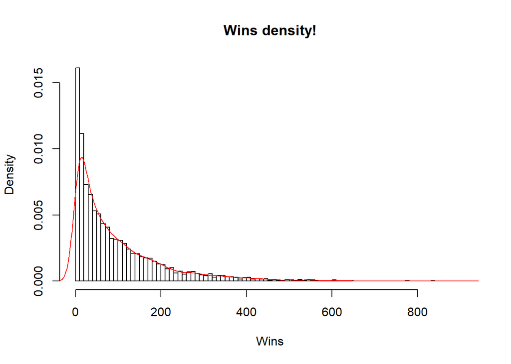

```r
COPY2 <- COPY[Indexes,]

#check the plot
hist(COPY2$wins,
     breaks = 100,
     prob = TRUE,
     main = "Wins density!",
     xlab = "Wins")

## Sample density
lines(density(COPY2$wins), col="red") #kinda perfectly as before ehehe
```

```r
tier2 <- Changer(COPY2$tier)


Wins2 <- COPY2$wins
LP2 <- COPY2$leaguePoints
tier2 <- tier2
N2 <- length(Wins2)
tierstypes2 <- 6 #number of tiers

dat.jags <- list(Wins = Wins2, LP = LP2, tier = tier2, N = N2, tierstypes = tierstypes2)
```

```r
set.seed(123)
#call it model5 since is the 4th of our project!

model7 <- function() {
  # Likelihood
  for(i in 1:N)
  {
    #for now we just leave the rate parameters as in simulation as dependence
    Wins[i]  ~ dgamma( shape[i], scale[i])

    shape[i] <- (base/(LP[i]+alpha))
    scale[i] <- (a1tiers[tier[i]])

  }

  # Priors

  alpha ~ dunif(0.9, 1.3)
  base ~ dunif(101, 105)
  for (i in 1 : tierstypes)
  {
    a1tiers[i] ~ dunif(20-i/3,  20 + i/3 ) #as explained we want it to grow with the rank
  }

}


mod.params7 <- c( 'a1tiers','base', 'alpha')

mod.fit <- jags(data = dat.jags,                                    # DATA
                model.file = model7, #inits = mod.inits,          # MODEL
                parameters.to.save = mod.params7,
                n.chains = 3, n.iter = 9000, n.burnin = 1000, n.thin=10)
#Autocorrelation produces clumpy samples that are unrepresentative, in the short run, of the true underlying posterior distribution. Therefore, if #possible, we would like to get rid of autocorrelation so that the MCMC sample provides a more precise estimate of the posterior sample. One way #to decrease autocorrelation is to thin the sample, using only every nth step.


mod.fit
```

```
## Inference for Bugs model at "C:/Users/leona/AppData/Local/Temp/Rtmp0CiPRT/model266428921086.txt", fit using jags,
##  3 chains, each with 9000 iterations (first 1000 discarded), n.thin = 10
##  n.sims = 2400 iterations saved
##                 mu.vect sd.vect        2.5%          25%          50%
## a1tiers[1]       19.667   0.000 1.96670e+01       19.667       19.667
## a1tiers[2]       19.333   0.000 1.93330e+01       19.333       19.333
## a1tiers[3]       19.000   0.000 1.90000e+01       19.000       19.000
## a1tiers[4]       18.667   0.000 1.86670e+01       18.667       18.667
## a1tiers[5]       18.333   0.000 1.83330e+01       18.333       18.333
## a1tiers[6]       18.000   0.000 1.80000e+01       18.000       18.000
## alpha             0.900   0.000 9.00000e-01        0.900        0.900
## base            104.999   0.001 1.04997e+02      104.999      104.999
## deviance   21775610.091   5.720 2.17756e+07 21775605.866 21775609.419
##                     75%        97.5% Rhat n.eff
## a1tiers[1]       19.667       19.667    1     1
## a1tiers[2]       19.333       19.333    1     1
## a1tiers[3]       19.000       19.000    1     1
## a1tiers[4]       18.667       18.667    1     1
## a1tiers[5]       18.333       18.333    1     1
## a1tiers[6]       18.000       18.000    1     1
## alpha             0.900        0.900    1     1
## base            105.000      105.000    1     1
## deviance   21775613.494 21775623.332    1     1
##
## For each parameter, n.eff is a crude measure of effective sample size,
## and Rhat is the potential scale reduction factor (at convergence, Rhat=1).
##
## DIC info (using the rule, pD = var(deviance)/2)
## pD = 16.4 and DIC = 21775626.5
## DIC is an estimate of expected predictive error (lower deviance is better).
```

```r
mod.fit$BUGSoutput$summary
```

```
##                    mean           sd         2.5%          25%          50%
## a1tiers[1] 1.966670e+01 2.970223e-05 1.966667e+01 1.966668e+01 1.966669e+01
## a1tiers[2] 1.933337e+01 3.569998e-05 1.933333e+01 1.933334e+01 1.933336e+01
## a1tiers[3] 1.900001e+01 1.121190e-05 1.900000e+01 1.900000e+01 1.900001e+01
## a1tiers[4] 1.866667e+01 7.928635e-06 1.866667e+01 1.866667e+01 1.866667e+01
## a1tiers[5] 1.833334e+01 6.959630e-06 1.833333e+01 1.833334e+01 1.833334e+01
## a1tiers[6] 1.800001e+01 5.874985e-06 1.800000e+01 1.800000e+01 1.800000e+01
## alpha      9.000591e-01 6.045106e-05 9.000012e-01 9.000168e-01 9.000395e-01
## base       1.049993e+02 7.421344e-04 1.049973e+02 1.049990e+02 1.049995e+02
## deviance   2.177561e+07 5.719967e+00 2.177560e+07 2.177561e+07 2.177561e+07
##                     75%        97.5% Rhat n.eff
## a1tiers[1] 1.966671e+01 1.966677e+01    1     1
## a1tiers[2] 1.933338e+01 1.933347e+01    1     1
## a1tiers[3] 1.900002e+01 1.900004e+01    1     1
## a1tiers[4] 1.866668e+01 1.866670e+01    1     1
## a1tiers[5] 1.833334e+01 1.833336e+01    1     1
## a1tiers[6] 1.800001e+01 1.800002e+01    1     1
## alpha      9.000813e-01 9.002232e-01    1     1
## base       1.049998e+02 1.050000e+02    1     1
## deviance   2.177561e+07 2.177562e+07    1     1
```

This DIC is extremely high, symptom of a bad model.

Same story for the Weibull we excluded the 0’s.

```r
set.seed(123)
#call it model9 since is the 9th of our project!

model9 <- function() {
  # Likelihood
  for(i in 1:N)
  {
    Wins[i]  ~ dweibull( shape[i], scale[i])

    shape[i] <- a1tiers[tier[i]]
    scale[i] <-  LP[i]/alpha + (alpha-LP[i])

  }
  # Priors
  alpha ~ dunif(95, 105)
  for (i in 1 : tierstypes)
  {
    a1tiers[i] ~ dunif(0.8-1/i^2, 0.9+1/i^2 ) #as explained we want it to grow with the rank
  }

}



mod.params9 <- c( 'a1tiers','alpha')

mod.fit <- jags(data = dat.jags,                                    # DATA
                model.file = model9, #inits = mod.inits,          # MODEL
                parameters.to.save = mod.params9,
                n.chains = 3, n.iter = 9000, n.burnin = 1000, n.thin=10)
#Autocorrelation produces clumpy samples that are unrepresentative, in the short run, of the true underlying posterior distribution. Therefore, if #possible, we would like to get rid of autocorrelation so that the MCMC sample provides a more precise estimate of the posterior sample. One way #to decrease autocorrelation is to thin the sample, using only every nth step.


mod.fit
```

```
## Inference for Bugs model at "C:/Users/leona/AppData/Local/Temp/Rtmp0CiPRT/model2664dbed8d.txt", fit using jags,
##  3 chains, each with 9000 iterations (first 1000 discarded), n.thin = 10
##  n.sims = 2400 iterations saved
##                 mu.vect sd.vect         2.5%          25%          50%
## a1tiers[1]        0.007   0.000        0.007        0.007        0.007
## a1tiers[2]        0.550   0.000        0.550        0.550        0.550
## a1tiers[3]        0.689   0.000        0.689        0.689        0.689
## a1tiers[4]        0.738   0.000        0.738        0.738        0.738
## a1tiers[5]        0.760   0.000        0.760        0.760        0.760
## a1tiers[6]        0.772   0.000        0.772        0.772        0.772
## alpha            98.992   0.000       98.992       98.992       98.992
## deviance   17081370.144   4.851 17081362.331 17081366.634 17081369.490
##                     75%        97.5% Rhat n.eff
## a1tiers[1]        0.007        0.008    1  2400
## a1tiers[2]        0.550        0.550    1     1
## a1tiers[3]        0.689        0.689    1     1
## a1tiers[4]        0.738        0.738    1     1
## a1tiers[5]        0.760        0.760    1     1
## a1tiers[6]        0.772        0.772    1     1
## alpha            98.992       98.992    1     1
## deviance   17081372.882 17081381.541    1     1
##
## For each parameter, n.eff is a crude measure of effective sample size,
## and Rhat is the potential scale reduction factor (at convergence, Rhat=1).
##
## DIC info (using the rule, pD = var(deviance)/2)
## pD = 11.8 and DIC = 17081381.9
## DIC is an estimate of expected predictive error (lower deviance is better).
```

```r
mod.fit$BUGSoutput$summary
```

```
##                    mean           sd         2.5%          25%          50%
## a1tiers[1] 7.292406e-03 2.255302e-04 6.863059e-03 7.139104e-03 7.290460e-03
## a1tiers[2] 5.500011e-01 1.087664e-06 5.500000e-01 5.500003e-01 5.500007e-01
## a1tiers[3] 6.888891e-01 2.058258e-07 6.888889e-01 6.888889e-01 6.888890e-01
## a1tiers[4] 7.375001e-01 1.112198e-07 7.375000e-01 7.375000e-01 7.375001e-01
## a1tiers[5] 7.600001e-01 7.917233e-08 7.600000e-01 7.600000e-01 7.600001e-01
## a1tiers[6] 7.722223e-01 6.011330e-08 7.722222e-01 7.722222e-01 7.722223e-01
## alpha      9.899222e+01 1.252073e-04 9.899198e+01 9.899213e+01 9.899221e+01
## deviance   1.708137e+07 4.851004e+00 1.708136e+07 1.708137e+07 1.708137e+07
##                     75%        97.5%     Rhat n.eff
## a1tiers[1] 7.440954e-03 7.742458e-03 1.000484  2400
## a1tiers[2] 5.500015e-01 5.500040e-01 1.000000     1
## a1tiers[3] 6.888892e-01 6.888896e-01 1.000000     1
## a1tiers[4] 7.375002e-01 7.375004e-01 1.000000     1
## a1tiers[5] 7.600001e-01 7.600003e-01 1.000000     1
## a1tiers[6] 7.722223e-01 7.722224e-01 1.000000     1
## alpha      9.899230e+01 9.899247e+01 1.000000     1
## deviance   1.708137e+07 1.708138e+07 1.000000     1
```

We already saw a very large DIC before, so probably this model is not well suited! ## Diagnostics So now let’s do some diagnostic for the best model, which has been decided is the Exponential! First we will run it a little more, instead of 9k iter we go with 39k, and we hope to see another improvement on it.

```r
#we have to take 1500 for every rank!
#so we make a copy of our dataset, and we drop lines!
COPY<-data.frame(LeagueData)
head(COPY)
```

```
##   tier     summonerName leaguePoints wins losses veteran
## 1 GOLD           T0kki3           52  183    169    True
## 2 GOLD    CrimsÃ\230nBlade            0   52     49   False
## 3 GOLD     I LIKE FLIES          100   56     56   False
## 4 GOLD     DaKin Kowine            2  197    191   False
## 5 GOLD AnatolÃ®an eagle            0    2     10   False
## 6 GOLD     TOXIC I Himi           18  174    197   False
```

```r
#Indexes <- c()
Iron <- which(COPY$tier == 'IRON')[1:1050]
Bronze <-which(COPY$tier == 'BRONZE')[1:1050]
Silver <-which(COPY$tier == 'SILVER')[1:1050]
Gold <-which(COPY$tier == 'GOLD')[1:1050]
Platinum <-which(COPY$tier == 'PLATINUM')[1:1050]
Diamond <- which(COPY$tier == 'DIAMOND')[1:1050]
Indexes<- c(Iron, Bronze, Silver, Gold, Platinum, Diamond)
head(COPY[Indexes,] ) #That's the subset
```

```
##       tier   summonerName leaguePoints wins losses veteran
## 19804 IRON        krstos1           75   60     79   False
## 19805 IRON       duktrill           31   14     25   False
## 19806 IRON jetz komme ich            7    7     46   False
## 19807 IRON sandrius922002           58    4     12   False
## 19808 IRON    DR procktor            6   18     31   False
## 19809 IRON       mamomo96           29    7     18   False
```

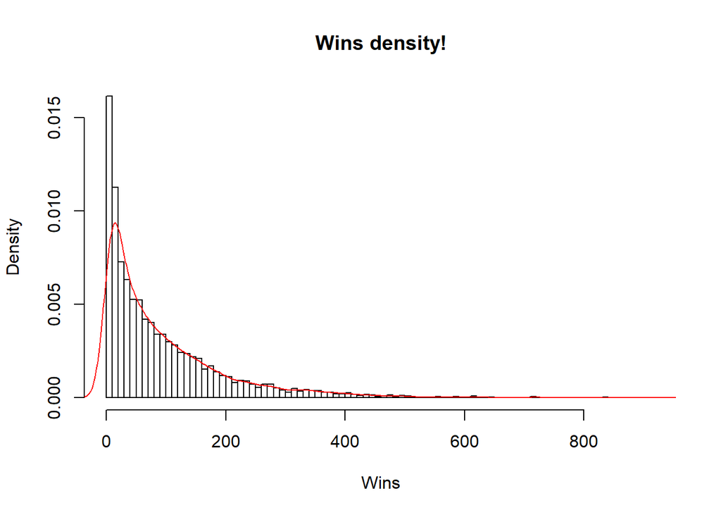

```r
COPY2 <- COPY[Indexes,]

#check the plot
hist(COPY2$wins,
     breaks = 100,
     prob = TRUE,
     main = "Wins density!",
     xlab = "Wins")

## Sample density
lines(density(COPY2$wins), col="red") #kinda perfectly as before ehehe
```

```r
tier2 <- Changer(COPY2$tier)


Wins2 <- COPY2$wins
LP2 <- COPY2$leaguePoints
tier2 <- tier2
N2 <- length(Wins2)
tierstypes2 <- 6 #number of tiers

dat.jags <- list(Wins = Wins2, LP = LP2, tier = tier2, N = N2, tierstypes = tierstypes2)
```

```r
set.seed(123)
#call it model5 since is the 5th of our project!

model5 <- function() {
  # Likelihood
  for(i in 1:N)
  {
    #for now we just leave the rate parameters as in simulation as dependence
    Wins[i]  ~ dexp( a1[i])# a1[i])#, a2[i])

    a1[i] <- (base/(a1tiers[tier[i]]+(a1Lp*LP[i]))^2)

   # Wins.rep[i] ~ dexp( a1[i])
  }

  # Priors
  base ~ dunif(0.2, 0.6)
  a1Lp ~ dunif(0, 0.05)
  for (i in 1 : tierstypes)
  {
    a1tiers[i] ~ dnorm(i, i ) #as explained we want it to grow with the rank
  }

}
mod.params5 <- c( 'a1tiers', 'a1Lp', 'base')

mod.fit <- jags(data = dat.jags,                                    # DATA
                model.file = model5, #inits = mod.inits,          # MODEL
                parameters.to.save = mod.params5,
                n.chains = 3, n.iter = 39000, n.burnin = 2000, n.thin=10)
#Autocorrelation produces clumpy samples that are unrepresentative, in the short run, of the true underlying posterior distribution. Therefore, if #possible, we would like to get rid of autocorrelation so that the MCMC sample provides a more precise estimate of the posterior sample. One way #to decrease autocorrelation is to thin the sample, using only every nth step.


mod.fit
```

```
## Inference for Bugs model at "C:/Users/leona/AppData/Local/Temp/Rtmp0CiPRT/model266411706ca1.txt", fit using jags,
##  3 chains, each with 39000 iterations (first 2000 discarded), n.thin = 10
##  n.sims = 11100 iterations saved
##              mu.vect sd.vect      2.5%       25%       50%       75%     97.5%
## a1Lp           0.000   0.000     0.000     0.000     0.000     0.000     0.001
## a1tiers[1]     2.623   0.066     2.514     2.577     2.616     2.661     2.770
## a1tiers[2]     2.352   0.059     2.254     2.311     2.345     2.386     2.486
## a1tiers[3]     4.124   0.102     3.955     4.053     4.113     4.182     4.359
## a1tiers[4]     4.905   0.119     4.710     4.823     4.892     4.974     5.178
## a1tiers[5]     5.377   0.129     5.162     5.287     5.361     5.451     5.669
## a1tiers[6]     5.889   0.141     5.652     5.791     5.876     5.967     6.206
## base           0.209   0.008     0.200     0.203     0.207     0.214     0.230
## deviance   67184.062   3.974 67178.243 67181.137 67183.422 67186.310 67193.361
##             Rhat n.eff
## a1Lp       1.001  4300
## a1tiers[1] 1.002  2200
## a1tiers[2] 1.002  1800
## a1tiers[3] 1.002  3100
## a1tiers[4] 1.003  1800
## a1tiers[5] 1.003  2900
## a1tiers[6] 1.002  3700
## base       1.005  1400
## deviance   1.000     1
##
## For each parameter, n.eff is a crude measure of effective sample size,
## and Rhat is the potential scale reduction factor (at convergence, Rhat=1).
##
## DIC info (using the rule, pD = var(deviance)/2)
## pD = 7.9 and DIC = 67192.0
## DIC is an estimate of expected predictive error (lower deviance is better).
```

```r
mod.fit$BUGSoutput$summary
```

```
##                    mean           sd         2.5%          25%          50%
## a1Lp       2.693453e-04 0.0002412001 6.536956e-06 8.701185e-05 2.027850e-04
## a1tiers[1] 2.623098e+00 0.0656843527 2.514079e+00 2.577178e+00 2.616085e+00
## a1tiers[2] 2.351681e+00 0.0588639202 2.253697e+00 2.310974e+00 2.344532e+00
## a1tiers[3] 4.124278e+00 0.1019190381 3.955254e+00 4.053378e+00 4.112852e+00
## a1tiers[4] 4.905388e+00 0.1190716241 4.709784e+00 4.822503e+00 4.891574e+00
## a1tiers[5] 5.376701e+00 0.1293007630 5.161748e+00 5.287188e+00 5.361034e+00
## a1tiers[6] 5.888921e+00 0.1407375407 5.651701e+00 5.791355e+00 5.875523e+00
## base       2.094981e-01 0.0082837508 2.002919e-01 2.032353e-01 2.073315e-01
## deviance   6.718406e+04 3.9735443738 6.717824e+04 6.718114e+04 6.718342e+04
##                     75%        97.5%     Rhat n.eff
## a1Lp       3.885352e-04 9.039947e-04 1.001334  4300
## a1tiers[1] 2.661269e+00 2.770135e+00 1.002373  2200
## a1tiers[2] 2.385692e+00 2.486192e+00 1.002125  1800
## a1tiers[3] 4.182073e+00 4.358835e+00 1.002002  3100
## a1tiers[4] 4.974156e+00 5.177934e+00 1.002763  1800
## a1tiers[5] 5.451029e+00 5.668616e+00 1.002797  2900
## a1tiers[6] 5.967354e+00 6.206180e+00 1.001522  3700
## base       2.136879e-01 2.303667e-01 1.005083  1400
## deviance   6.718631e+04 6.719336e+04 1.000000     1
```

Actually the results are almost the same as before, so good news and let’s go on!